# Chapter 7. Analysis of function: Sentence Modes

Analyses from PhD Thesis on Phonology and Phonetics of Derry City English Intonation

Antion Eoin Rodgers, Phonetics and Speech Laboratory, Trinity College Dublin

This page contains all analyses conducted in R for Chapter 7 of my PhD thesis on the phonology and phonetics of intonation in Derry City English (DCE). This particular chapter focuses on describing the intonation associated with sentence mode (declarative statements, wh-questions, yes-no questions and declarative questions).

There are are two key aims in this chapter. One is simply to provide a description of intonation and sentence mode in DCE within the Autosegmental Metrical (AM) framework. The other is theoretical and aims to assess the viability and descriptive efficiency of an AM analysis which includes a separate register tier alongside the tonal tier.

# Chapter 7.5: Phonological Analysis

## 7.5.1 Non-register-tier Analysis

### Raw Data

```r
tot_rows <- nrow(m_corpus)
threshold <- 8

keep_list <- m_corpus %>%
  mutate(phr_phon = factor(phr_phon, levels = unique(phr_phon))) %>%
  group_by(phr_phon) %>%
  summarise(phon_count = n()) %>%
  filter(phon_count >= 8)
```

#### Nuclear Pitch Accent by Speaker

```r
## Create summary table of Pitch Accent by Speaker.
m_corpus %>%
  group_by(speaker, acc_phon) %>%
  summarise(acc_count = n(), .groups = "keep") %>%
  pivot_wider(
    names_from = acc_phon,
    values_from = acc_count,
    values_fill = 0
  ) %>%
  select("speaker", "H*", "L*H", ">H*") %>%
  rename_all(list(~ str_replace_all(., "([\\*\\[\\^\\>])", "\\\\\\1"))) %>%
  adorn_totals(where = "row") %>%
  formattable(
    caption =
      "distribution by speaker of nuclear pitch accents in M-corpus (raw)",
    list(area(col = 2:4, row = 1:nrow(.) - 1) ~ proportion_bar(color = c(
      rep(brewer.pal(6, "Pastel2")[1], 11),
      rep(brewer.pal(6, "Pastel2")[3], 11),
      rep(brewer.pal(6, "Pastel2")[4], 11)
    )))
  )
```

distribution by speaker of nuclear pitch accents in M-corpus (raw)

| speaker | H* | L*H | >H* |
| --- | --- | --- | --- |
| F5 | 0 | 59 | 0 |
| F6 | 0 | 60 | 0 |
| F12 | 0 | 60 | 0 |
| F15 | 0 | 60 | 0 |
| F16 | 0 | 60 | 0 |
| F17 | 0 | 55 | 0 |
| M4 | 0 | 57 | 0 |
| M5 | 0 | 60 | 0 |
| M8 | 2 | 54 | 5 |
| M9 | 0 | 47 | 0 |
| M10 | 0 | 60 | 0 |
| Total | 2 | 632 | 5 |

#### Utterance Phonology (most common)

```r
m_corpus %>%
  mutate(phr_phon = factor(phr_phon, levels = unique(phr_phon))) %>%
  filter(phr_phon %in% keep_list$phr_phon) %>%
  group_by(mode, phr_phon) %>%
  summarise(phon_count = n(), .groups = "rowwise") %>%
  arrange(desc(phon_count)) %>%
  mutate(phr_phon = str_replace_all(
    phr_phon,
    "(\\*)", "\\\\\\1"
  )) %>%
  pivot_wider(
    names_from = mode,
    values_from = phon_count,
    values_fill = 0
  ) %>%
  select(phr_phon, MDC, MWH, MYN, MDQ) %>%
  rowwise(phr_phon) %>%
  mutate(total = sum(c_across())) %>%
  tibble::rowid_to_column("#") %>%
  rename("Phonology" = phr_phon) %>%
  formattable(
    align = "r",
    caption = paste(
      "Utterance level intonational phonology by mode ",
      "for tokens accounting for at least ",
      percent(threshold / tot_rows),
      " of all tokens.",
      sep = ""
    ),
    list(
      area(col = 3:6) ~ proportion_bar(color = c(
        rep(brewer.pal(4, "Pastel2")[3], nrow(.)),
        rep(brewer.pal(4, "Pastel2")[2], nrow(.)),
        rep(brewer.pal(4, "Pastel2")[1], nrow(.)),
        rep(brewer.pal(4, "Pastel2")[4], nrow(.))
      )),
      total = proportion_bar(color = "#aaaaaa")
    )
  )
```

Utterance level intonational phonology by mode for tokens accounting for at least 1.25% of all tokens.

| # | Phonology | MDC | MWH | MYN | MDQ | total |
| --- | --- | --- | --- | --- | --- | --- |
| 1 | % H* L* L*H % | 5 | 54 | 0 | 0 | 59 |
| 2 | % >H* L*H % | 30 | 0 | 38 | 27 | 95 |
| 3 | % L*H % | 32 | 0 | 37 | 28 | 97 |
| 4 | % H* L*H % | 33 | 0 | 11 | 5 | 49 |
| 5 | % L*H L*H % | 25 | 0 | 29 | 24 | 78 |
| 6 | % H* L*!H L*H % | 0 | 21 | 0 | 0 | 21 |
| 7 | % H* L*H L*H % | 0 | 17 | 0 | 0 | 17 |
| 8 | % H* !H* L*H % | 5 | 17 | 0 | 0 | 22 |
| 9 | % L*H L% | 1 | 0 | 12 | 12 | 25 |
| 10 | % >H* L*H L% | 10 | 0 | 8 | 11 | 29 |
| 11 | % H* L*H L% | 6 | 0 | 4 | 10 | 20 |
| 12 | % L*H H% | 0 | 0 | 4 | 9 | 13 |
| 13 | % >H* L*!H L*H % | 0 | 8 | 0 | 0 | 8 |
| 14 | % H* L*H % | 3 | 8 | 1 | 0 | 12 |
| 15 | % L*H L*H L% | 1 | 0 | 1 | 8 | 10 |

#### Utterance Phonology (all)

```r
m_corpus %>%
  mutate(phr_phon = factor(phr_phon, levels = unique(phr_phon))) %>%
  group_by(phr_phon) %>%
  summarise(phon_count = n()) %>%
  arrange(desc(phon_count)) %>%
  mutate(phr_phon = str_replace_all(
    phr_phon,
    "([\\*\\[\\^\\>])",
    "\\\\\\1"
  )) %>%
  formattable(
    caption = paste(
      "Utterance level intonational phonology without Register Tier",
      "in M-corpus for all tokens."
    )
  )
```

Utterance level intonational phonology without Register Tier in M-corpus for all tokens.

| phr_phon | phon_count |
| --- | --- |
| % L*H % | 97 |
| % >H* L*H % | 95 |
| % L*H L*H % | 78 |
| % H* L* L*H % | 59 |
| % H* L*H % | 49 |
| % >H* L*H L% | 29 |
| % L*H L% | 25 |
| % H* !H* L*H % | 22 |
| % H* L*!H L*H % | 21 |
| % H* L*H L% | 20 |
| % H* L*H L*H % | 17 |
| % L*H H% | 13 |
| % H* L*H % | 12 |
| % L*H L*H L% | 10 |
| % >H* L*!H L*H % | 8 |
| % L*H L*!H L*H L% | 6 |
| % >H* L* L*H % | 5 |
| % H* L* L*H L% | 5 |
| %H L*H L*H % | 5 |
| %H L*H % | 5 |
| % H* L*H L% | 5 |
| % L*H L*H H% | 3 |
| % >H* L*H H% | 3 |
| %H L* L*H % | 3 |
| %H L*!H L*H % | 3 |
| %H >H* L*!H L*H % | 3 |
| % L* L*H % | 3 |
| % H* L*H H% | 3 |
| % H* >H* L% | 3 |
| % L*H L% | 3 |
| % L*H % | 2 |
| % H* H* L% | 2 |
| % L*H HL% | 1 |
| % H* L*H HL% | 1 |
| %H H* L* L*H % | 1 |
| % >H* L*H L*H % | 1 |
| % H* L*!H L*H L% | 1 |
| % L*H L* L*H L% | 1 |
| % >H* L* L*H L% | 1 |
| %H >H* L*H % | 1 |
| %H >!H* L*H % | 1 |
| %H H* L*H L*H % | 1 |
| %L H* L*H % | 1 |
| % H* !H*L L*H % | 1 |
| % H* >!H* L*H % | 1 |
| %H !H* L*H % | 1 |
| % >H* L*H % | 1 |
| % >H* >H* L% | 1 |
| % >H* L% | 1 |
| % L*H L*H % | 1 |
| % L*H L*H L% | 1 |
| %L H* L*H L% | 1 |
| % L*H L*H L*H % | 1 |
| % >H*> L*H % | 1 |

### Adjusted Data

The raw data is unbalanced since there number of utterances per target speaker varies slightly. For some speakers, there are no repetitions of some target utterances. Therefore, the data has been adjusted to project an estimated balanced number of tokens per speaker per target utterance.

Firstly a tibble is created summarising the proportion of pitch accents per mode per speaker. This is done in three initial stages:

1. Count the number of phonological tokens per stimulus per speaker.
2. Convert the counts to proportion per stimulus per speaker.
3. Convert the proportion per stimulus per speaker proportion per stimulus per mode.

From this table to summary tables are created:

1. pitch accents per speaker (adjusted)
   1. Calculate the sum all proportions per token per speaker.
   2. Convert proportions to an integer based on an ideal total number of tokens per speaker.
2. pitch accents per speaker (adjusted):
   1. Calculate the sum all proportions per token per mode.
   2. Convert proportions to an integer based on an ideal total number of tokens per mode
3. pitch accents by gender and mode (adjusted):
   1. Calculate the sum all proportions per token by mode and gender.
   2. Convert proportions to an integer based on an ideal total number of tokens per mode as if there were an equal number of male and female participants.

```r
## Create tibble summarising  proportion of pitch accents per mode per speaker
pa_adj <- m_corpus %>%
  ## Count the number of acc_phon by speaker and mode
  group_by(speaker, stim, acc_phon) %>%
  summarise(nuc_count = n(), .groups = "keep") %>%
  pivot_wider(
    names_from = acc_phon,
    values_from = nuc_count,
    values_fill = 0
  ) %>%
  ## convert the totals to proportion per stim.
  adorn_totals("col") %>%
  mutate(across(3:5, ~ (. / Total))) %>%
  select(-Total) %>%
  ## Convert stim column to mode.
  rename(mode = stim) %>%
  mutate(mode = substr(mode, 1, 3)) %>%
  ## Convert the values to proportion per mode
  pivot_longer(3:last_col(), names_to = "acc_phon") %>%
  group_by(speaker, mode, acc_phon) %>%
  pivot_wider(
    names_from = acc_phon,
    values_from = value,
    values_fill = 0,
    values_fn = ~ sum(.)
  ) %>%
  adorn_totals("col") %>%
  mutate(across(3:5, ~ (. / Total)),
    mode = factor(mode, levels = c("MDC", "MWH", "MYN", "MDQ"))
  ) %>%
  select(-Total) %>%
  as_tibble()

## Create tibble of pitch accents per speaker (adjusted).
pa_by_speaker_adj <- pa_adj %>%
  ## Get the sum of all token proportions per speaker.
  pivot_longer(3:last_col(), names_to = "acc_phon") %>%
  select(-mode) %>%
  pivot_wider(
    names_from = acc_phon,
    values_from = value,
    values_fill = 0,
    values_fn = ~ sum(.)
  ) %>%
  ## Convert proportions to an integer based on an ideal total number of tokens
  ## per speaker.
  mutate(across(2:4, ~ round(. * 15, 0))) %>%
  select("speaker", "H*", "L*H", ">H*")

## Create tibble of pitch accents per mode (adjusted).
pa_by_mode_adj <- pa_adj %>%
  ## Get the sum of all token proportions per speaker.
  pivot_longer(3:last_col(), names_to = "acc_phon") %>%
  select(-speaker) %>%
  pivot_wider(
    names_from = acc_phon,
    values_from = value,
    values_fill = 0,
    values_fn = ~ sum(.)
  ) %>%
  ## Convert proportions to an integer based on an ideal total number of tokens.
  mutate(across(2:4, ~ round(. * 15, 0))) %>%
  select("mode", "H*", "L*H", ">H*") %>%
  arrange(mode)

## Create tibble of pitch accents by gender and mode (adjusted).
pa_by_gender_adj <- pa_adj %>%
  ## Convert gender to speaker
  mutate(
    speaker = substr(speaker, 1, 1),
    speaker = factor(speaker, levels = unique(speaker))
  ) %>%
  rename(gender = speaker) %>%
  ## Get the sum of all token proportions per speaker.
  pivot_longer(3:last_col(), names_to = "acc_phon") %>%
  pivot_wider(
    names_from = acc_phon,
    values_from = value,
    values_fill = 0,
    values_fn = ~ sum(.)
  ) %>%
  ## Convert proportions to an integer based on an ideal total number of tokens
  ## per speaker.
  mutate(across(3:5, ~ if_else(
    gender == "F",
    round(. * 15, 0),
    ## project equal number of Male & Female speakers.
    round(. * 18, 0)
  ))) %>%
  select("mode", "gender", "H*", "L*H", ">H*") %>%
  arrange(mode)
```

#### Nuclear Pitch Accent

##### By speaker (table)

```r
pa_by_speaker_adj %>%
  rename_all(list(~ str_replace_all(., "([\\*\\[\\^\\>])", "\\\\\\1"))) %>%
  adorn_totals(where = "row") %>%
  formattable(
    caption =
      "distribution by speaker of nuclear pitch accents in M-corpus (adjusted)",
    list(area(col = 2:4, row = 1:nrow(.) - 1) ~ proportion_bar(
      color = c(
        rep(brewer.pal(6, "Pastel2")[1], nrow(.) - 1),
        rep(brewer.pal(6, "Pastel2")[3], nrow(.) - 1),
        rep(brewer.pal(6, "Pastel2")[4], nrow(.) - 1)
      )
    ))
  )
```

distribution by speaker of nuclear pitch accents in M-corpus (adjusted)

| speaker | H* | L*H | >H* |
| --- | --- | --- | --- |
| F5 | 0 | 60 | 0 |
| F6 | 0 | 60 | 0 |
| F12 | 0 | 60 | 0 |
| F15 | 0 | 60 | 0 |
| F16 | 0 | 60 | 0 |
| F17 | 0 | 60 | 0 |
| M4 | 0 | 60 | 0 |
| M5 | 0 | 60 | 0 |
| M8 | 2 | 54 | 5 |
| M9 | 0 | 60 | 0 |
| M10 | 0 | 60 | 0 |
| Total | 2 | 654 | 5 |

##### By speaker (Bar chart)

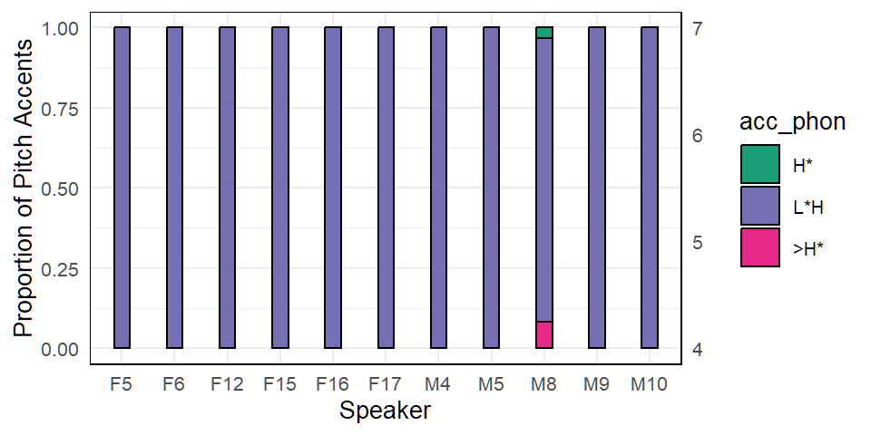

```r
## Percentage Stacked bar

ggplot(
  pa_by_speaker_adj %>%
    # uncount data for chart
    gather("acc_phon", "count", -c(speaker)) %>%
    uncount(count) %>%
    mutate(acc_phon = factor(acc_phon, levels = unique(acc_phon))),
  aes(fill = acc_phon, x = speaker)
) +
  geom_bar(
    stat = "count",
    position = "fill",
    width = 0.30,
    colour = "black"
  ) +
  scale_fill_manual(
    values = pitch_accent_colours[
      colnames(pa_by_speaker_adj[2:length(pa_by_speaker_adj)])
    ]
  ) +
  labs(y = "Proportion of Pitch Accents", x = "Speaker") +
  theme(panel.border = element_rect(fill = NA)) +
  scale_y_continuous(sec.axis = sec_axis(~ . * 3 + 4))
```

##### By Sentence Mode

```r
## Calculate a projected balanced number of tokens for each PA as a function of
## sentence mode.
#
## This takes into consideration the number of utterances per speaker per stimulus and the number of speakers per stimulus.

pa_by_mode_adj %>%
  rename_all(list(~ str_replace_all(., "([\\*\\[\\^\\>])", "\\\\\\1"))) %>%
  adorn_totals("row") %>%
  formattable(
    caption =
      "distribution by mode of nuclear pitch accents in M-corpus (adjusted)",
    list(area(col = 2:4, row = 1:4) ~ proportion_bar(color = c(
      rep(brewer.pal(6, "Pastel2")[1], 4),
      rep(brewer.pal(6, "Pastel2")[3], 4),
      rep(brewer.pal(6, "Pastel2")[4], 4)
    )))
  )
```

distribution by mode of nuclear pitch accents in M-corpus (adjusted)

| mode | H* | L*H | >H* |
| --- | --- | --- | --- |
| MDC | 2 | 162 | 2 |
| MWH | 0 | 165 | 0 |
| MYN | 0 | 163 | 2 |
| MDQ | 0 | 164 | 1 |
| Total | 2 | 654 | 5 |

It is clear that there is little relationship between the pitch accent and mode when the register tier is discounted. However, looking at the raw data for the phrase-level phonology, it looks like L% boundaries are more commonly associated with questions than declarative.

Therefore, it might be worth looking at the nuclear contour as a whole in this data set.

#### Nuclear Pitch Contour

```r
## Create tibble summarising nuclear contours per mode per speaker
nuc_contour_adj <- m_corpus %>%
  ## Count the number of nuc_contour by speaker and mode
  group_by(speaker, stim, nuc_contour) %>%
  summarise(nuc_count = n(), .groups = "keep") %>%
  pivot_wider(
    names_from = nuc_contour,
    values_from = nuc_count,
    values_fill = 0
  ) %>%
  ## convert the totals to proportion per stim.
  adorn_totals("col") %>%
  mutate(across(3:6, ~ (. / Total))) %>%
  select(-Total) %>%
  ## Convert stim column to mode.
  rename(mode = stim) %>%
  mutate(mode = substr(mode, 1, 3)) %>%
  ## Convert the values to proportion per mode
  pivot_longer(3:last_col(), names_to = "nuc_contour") %>%
  group_by(speaker, mode, nuc_contour) %>%
  pivot_wider(
    names_from = nuc_contour,
    values_from = value,
    values_fill = 0,
    values_fn = ~ sum(.)
  ) %>%
  adorn_totals("col") %>%
  mutate(across(3:6, ~ (. / Total)),
    mode = factor(mode, levels = c("MDC", "MWH", "MYN", "MDQ"))
  ) %>%
  select(-Total) %>%
  as_tibble()

## Create tibble of nuclear contours per speaker (adjusted).
nuc_contour_by_speaker_adj <- nuc_contour_adj %>%
  ## Get the sum of all token proportions per speaker.
  pivot_longer(3:last_col(), names_to = "nuc_contour") %>%
  select(-c(mode)) %>%
  pivot_wider(
    names_from = nuc_contour,
    values_from = value,
    values_fill = 0,
    values_fn = ~ sum(.)
  ) %>%
  ## Convert proportions to an integer based on an ideal total number of tokens
  ## per speaker.
  mutate(across(2:5, ~ round(. * 15, 0)))

## Create tibble of nuclear contours per mode (adjusted).
nuc_contour_by_mode_adj <- nuc_contour_adj %>%
  ## Get the sum of all token proportions per speaker.
  pivot_longer(3:last_col(), names_to = "nuc_contour") %>%
  select(-c(speaker)) %>%
  pivot_wider(
    names_from = nuc_contour,
    values_from = value,
    values_fill = 0,
    values_fn = ~ sum(.)
  ) %>%
  ## Convert proportions to an integer based on an ideal total number of tokens.
  mutate(across(2:5, ~ round(. * 15, 0))) %>%
  arrange(mode)

## Create tibble of nuclear contours by gender and mode (adjusted).
nuc_contour_by_gender_adj <- nuc_contour_adj %>%
  ## Convert gender to speaker
  mutate(
    speaker = substr(speaker, 1, 1),
    speaker = factor(speaker, levels = unique(speaker))
  ) %>%
  rename(gender = speaker) %>%
  ## Get the sum of all token proportions per speaker.
  pivot_longer(3:last_col(), names_to = "nuc_contour") %>%
  pivot_wider(
    names_from = nuc_contour,
    values_from = value,
    values_fill = 0,
    values_fn = ~ sum(.)
  ) %>%
  ## Convert proportions to an integer based on an ideal total number of tokens
  ## per speaker.
  mutate(across(3:6, ~ if_else(gender == "F",
    round(. * 15, 0),
    ## project equal number of Male & Female speakers.
    round(. * 18, 0)
  ))) %>%
  arrange(mode)
```

##### By speaker and sentence mode (table)

```r
nuc_contour_by_speaker_adj %>%
  rename_all(list(~ str_replace_all(., "([\\*\\[\\^\\>])", "\\\\\\1"))) %>%
  adorn_totals(where = "row") %>%
  formattable(
    caption = "distribution by speaker of nuclear contours in M-corpus (adjusted)",
    align = "r",
    list(area(col = 2:7, row = 1:nrow(.) - 1) ~ proportion_bar(color = c(
      rep(brewer.pal(8, "Pastel2")[3], nrow(.) - 1),
      rep(brewer.pal(8, "Pastel2")[7], nrow(.) - 1),
      rep(brewer.pal(8, "Pastel2")[2], nrow(.) - 1),
      rep(brewer.pal(8, "Pastel2")[8], nrow(.) - 1),
      rep(brewer.pal(8, "Pastel2")[4], nrow(.) - 1),
      rep(brewer.pal(8, "Pastel2")[1], nrow(.) - 1)
    )))
  )
```

distribution by speaker of nuclear contours in M-corpus (adjusted)

| speaker | L*H % | L*H L% | L*H H% | L*H HL% | >H* L% | H* L% |
| --- | --- | --- | --- | --- | --- | --- |
| F5 | 32 | 15 | 7 | 6 | 0 | 0 |
| F6 | 53 | 2 | 3 | 2 | 0 | 0 |
| F12 | 21 | 38 | 1 | 0 | 0 | 0 |
| F15 | 53 | 3 | 4 | 0 | 0 | 0 |
| F16 | 59 | 0 | 1 | 0 | 0 | 0 |
| F17 | 54 | 5 | 1 | 0 | 0 | 0 |
| M4 | 55 | 0 | 5 | 0 | 0 | 0 |
| M5 | 60 | 0 | 0 | 0 | 0 | 0 |
| M8 | 27 | 13 | 0 | 0 | 5 | 2 |
| M9 | 36 | 24 | 0 | 0 | 0 | 0 |
| M10 | 44 | 16 | 0 | 0 | 0 | 0 |
| Total | 494 | 116 | 22 | 8 | 5 | 2 |

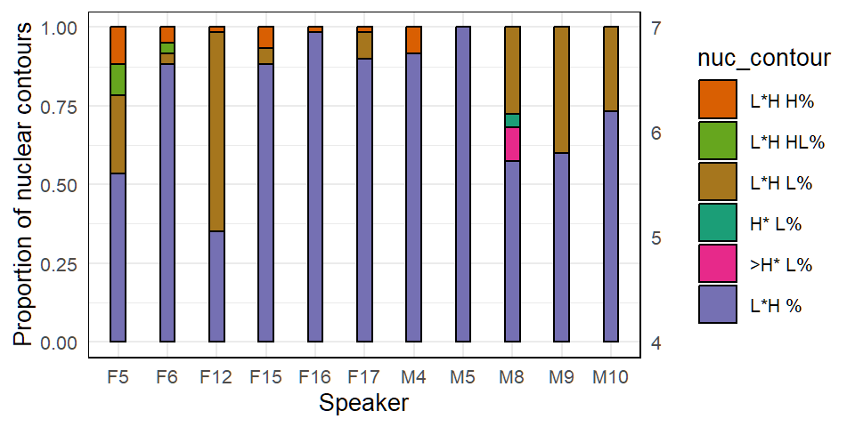

```r
## Percentage Stacked bar
ggplot(
  data = nuc_contour_by_speaker_adj %>%
    ## Uncount table for bar chart
    gather("nuc_contour", "count", -c(speaker)) %>%
    uncount(count) %>%
    # arrange levels
    mutate(nuc_contour = factor(
      nuc_contour,
      levels =
        c("L*H H%", "L*H HL%", "L*H L%", "H* L%", ">H* L%", "L*H %")
    )),
  aes(fill = nuc_contour, x = speaker)
) +
  geom_bar(
    stat = "count",
    position = "fill",
    width = 0.30,
    colour = "black"
  ) +
  scale_fill_manual(values = nuc_contour_colours
  [colnames(
      nuc_contour_by_speaker_adj[2:length(
        nuc_contour_by_speaker_adj
      )]
    )]) +
  labs(
    y = "Proportion of nuclear contours",
    x = "Speaker"
  ) +
  theme(panel.border = element_rect(fill = NA)) +
  scale_y_continuous(sec.axis = sec_axis(~ . * 3 + 4))
```

##### By nuclear pitch contour and sentence mode

```r
## Calculate a projected balanced number of tokens for each PA as a function of
## sentence mode.
#
## This takes into consideration the number of utterances per speaker per
## stimulus and the number of speakers per stimulus.

nuc_contour_by_mode_adj %>%
  rename_all(list(~ str_replace_all(., "([\\*\\[\\^\\>])", "\\\\\\1"))) %>%
  adorn_totals("row") %>%
  formattable(
    caption =
      "distribution by mode of nuclear contours in M-corpus (adjusted)",
    list(area(col = 2:7, row = 1:nrow(.) - 1) ~ proportion_bar(color = c(
      rep(brewer.pal(8, "Pastel2")[3], nrow(.) - 1),
      rep(brewer.pal(8, "Pastel2")[7], nrow(.) - 1),
      rep(brewer.pal(8, "Pastel2")[2], nrow(.) - 1),
      rep(brewer.pal(8, "Pastel2")[8], nrow(.) - 1),
      rep(brewer.pal(8, "Pastel2")[4], nrow(.) - 1),
      rep(brewer.pal(8, "Pastel2")[1], nrow(.) - 1)
    )))
  )
```

distribution by mode of nuclear contours in M-corpus (adjusted)

| mode | L*H % | L*H L% | L*H H% | L*H HL% | >H* L% | H* L% |
| --- | --- | --- | --- | --- | --- | --- |
| MDC | 139 | 17 | 0 | 0 | 2 | 2 |
| MWH | 148 | 17 | 0 | 0 | 0 | 0 |
| MYN | 124 | 29 | 5 | 0 | 2 | 0 |
| MDQ | 82 | 54 | 17 | 8 | 1 | 0 |
| Total | 493 | 117 | 22 | 8 | 5 | 2 |

#### Contour by Mode and Gender

It appears that the male speakers are more likely to begin using L% across the question mode hierarchy more than the female speakers. There are not enough speakers, I believe, however, to justify this as a general conclusion, especially as it is only M8, M9, and M10 who do this.

##### Common contours

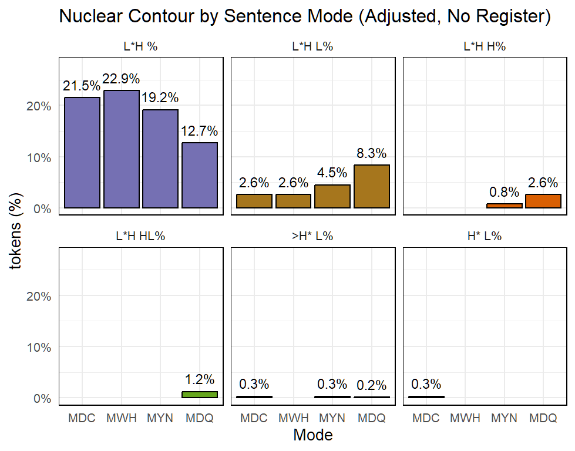

```r
my_plot <- ggplot(
  nuc_contour_by_mode_adj %>%
    ## Uncount table for bar chart.
    pivot_longer(2:last_col(), names_to = "nuc_contour") %>%
    uncount(value) %>%
    mutate(
      nuc_contour =
        factor(
          nuc_contour,
          levels = c(
            "L*H %", "L*H L%", "L*H H%", "L*H HL%", ">H* L%", "H* L%"
          )
        )
    )
) +
  geom_bar(
    mapping = aes(
      x = mode,
      y = (after_stat(count)) / sum(after_stat(count)),
      fill = nuc_contour
    ),
    show.legend = F,
    colour = "black",
    position = position_dodge2(preserve = "single")
  ) +
  scale_y_continuous(labels = scales::percent, limits = c(0, 0.28)) +
  facet_wrap(~nuc_contour, nrow = 2) +
  theme(panel.border = element_rect(fill = NA)) +
  ggtitle("Nuclear Contour by Sentence Mode (Adjusted, No Register)") +
  scale_fill_manual(values = nuc_contour_colours, name = "nuclear contour") +
  labs(x = "Mode", y = "tokens (%)") +
  theme(panel.border = element_rect(fill = NA)) +
  geom_text(
    aes(
      x = mode,
      y = (after_stat(count)) / sum(after_stat(count)),
      label = percent((after_stat(count)) / sum(after_stat(count)), 1)
    ),
    stat = "count",
    vjust = -0.75,
    size = 3
  )
ggsave(
  filename =
    "output/nuc_contour_by_mode.png",
  plot = my_plot,
  width = 12.95,
  height = 10.16,
  units = "cm",
  dpi = 300
)

my_plot
```

##### All contours

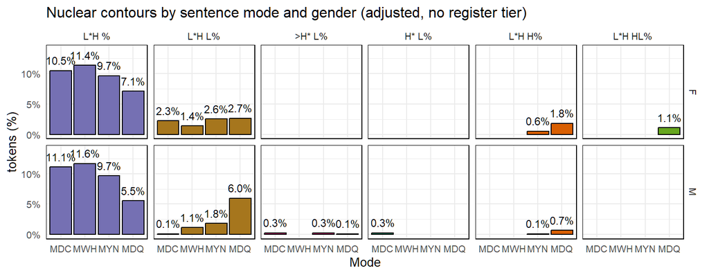

```r
my_plot <- ggplot(
  nuc_contour_by_gender_adj %>%
    ## uncount date for chart
    pivot_longer(3:last_col(), names_to = "nuc_contour") %>%
    uncount(value) %>%
    mutate(nuc_contour = factor(nuc_contour, levels = unique(nuc_contour))) ## %>%
  # filter(nuc_contour %notin% c(">H* L%", "H* L%"))
) +
  geom_bar(
    mapping = aes(
      x = mode,
      y = (after_stat(count)) / sum(after_stat(count)),
      fill = nuc_contour
    ),
    show.legend = F,
    colour = "black",
    position = position_dodge2(preserve = "single")
  ) +
  scale_y_continuous(labels = scales::percent, limits = c(0, 0.14)) +
  facet_grid(rows = vars(gender), cols = vars(nuc_contour)) +
  theme(
    panel.border = element_rect(fill = NA)
  ) +
  ggtitle(
    "Nuclear contours by sentence mode and gender (adjusted, no register tier)"
  ) +
  scale_fill_manual(values = nuc_contour_colours, name = "nuclear contour") +
  labs(x = "Mode", y = "tokens (%)") +
  theme(panel.border = element_rect(fill = NA)) +
  geom_text(
    aes(
      x = mode,
      y = (after_stat(count)) / sum(after_stat(count)),
      label = percent((after_stat(count)) / sum(after_stat(count)), 1)
    ),
    stat = "count",
    vjust = -0.75,
    size = 3
  )

ggsave(
  filename =
    "output/nuc_contour_by_mode_gender_non_reg.png",
  plot = my_plot,
  width = 22,
  height = 8,
  units = "cm",
  dpi = 300
)
my_plot
```

The overall pattern suggest that L% is more common among YNQs and and DCQs. However, I don’t think that the L% is used to signal a question. I think that, as with the A&H corpus, L% is used when the speaker indicates there is a conflict of expectation of shared knowledge between the speaker and listener. Thus in questions like “You live in the valley?” and “Do you live in the valley?”, speaker can use the L% to indicate that the propositional content conflicts with what he or she had previously believed; i.e., it indicates surprise. In a reciprocal manner, in the declaratives of the A&H corpus (and here), the use of an L% indicates that the speaker is indicating surprise that the listener does not already share the knowledge. (i.e. “Where do you live?…”I live in the valley [L%] (and I assumed you already knew that / and you should know that already.”) … Perhaps the best way to think of this is as the surprise~redundancy strategy, with the conflict of expectations expressing redundancy in the declaratives (“This should not be news to you.”) and surprise in the questions (“I did not know this at all!”).

#### Boundary Tone Analysis

```r
fin_phon_adj <- m_corpus %>%
  ## Count the number of fin_phon by speaker and mode
  group_by(speaker, stim, fin_phon) %>%
  summarise(nuc_count = n(), .groups = "keep") %>%
  pivot_wider(
    names_from = fin_phon,
    values_from = nuc_count,
    values_fill = 0
  ) %>%
  ## convert the totals to proportion per stim.
  adorn_totals("col") %>%
  mutate(across(3:6, ~ (. / Total))) %>%
  select(-Total) %>%
  ## Convert stim column to mode.
  rename(mode = stim) %>%
  mutate(mode = substr(mode, 1, 3)) %>%
  ## Convert the values to proportion per mode
  pivot_longer(3:last_col(), names_to = "fin_phon") %>%
  group_by(speaker, mode, fin_phon) %>%
  pivot_wider(
    names_from = fin_phon,
    values_from = value,
    values_fill = 0,
    values_fn = ~ sum(.)
  ) %>%
  adorn_totals("col") %>%
  mutate(across(3:6, ~ (. / Total)),
    mode = factor(mode, levels = c("MDC", "MWH", "MYN", "MDQ"))
  ) %>%
  select(-Total) %>%
  as_tibble()

## Create tibble of final boundaries per mode (adjusted).
fin_phon_by_mode_adj <- fin_phon_adj %>%
  ## Get the sum of all token proportions per speaker.
  pivot_longer(3:last_col(), names_to = "fin_phon") %>%
  select(-c(speaker)) %>%
  pivot_wider(
    names_from = fin_phon,
    values_from = value,
    values_fill = 0,
    values_fn = ~ sum(.)
  ) %>%
  ## Convert proportions to an integer based on an ideal total number of tokens.
  mutate(across(2:5, ~ round(. * 15, 0))) %>%
  arrange(mode)

## Create tibble of final boundaries  by gender and mode (adjusted).
fin_phon_by_gender_adj <- fin_phon_adj %>%
  ## Convert gender to speaker
  mutate(
    speaker = substr(speaker, 1, 1),
    speaker = factor(speaker, levels = unique(speaker))
  ) %>%
  rename(gender = speaker) %>%
  ## Get the sum of all token proportions per speaker.
  pivot_longer(3:last_col(), names_to = "fin_phon") %>%
  pivot_wider(
    names_from = fin_phon,
    values_from = value,
    values_fill = 0,
    values_fn = ~ sum(.)
  ) %>%
  ## Convert proportions to an integer based on an ideal total number of tokens
  ## per speaker.
  mutate(across(3:6, ~ if_else(gender == "F",
    round(. * 15, 0),
    ## project equal number of Male & Female speakers.
    round(. * 18, 0)
  ))) %>%
  arrange(mode)

## Make lists of projected boundary tokens.
fin_phon_by_mode_adj_list <- fin_phon_by_mode_adj %>%
  pivot_longer(2:last_col(), names_to = "fin_phon") %>%
  uncount(value) %>%
  mutate(fin_phon = factor(fin_phon, levels = unique(fin_phon)))


## Get list of projected boundary tokens by mode and gender.
fin_phon_by_gender_adj_list <- fin_phon_by_gender_adj %>%
  pivot_longer(3:last_col(), names_to = "fin_phon") %>%
  uncount(value) %>%
  mutate(fin_phon = factor(fin_phon, levels = unique(fin_phon)))
```

##### by sentence mode

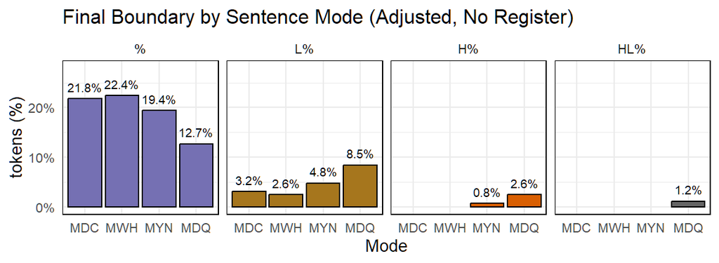

```r
my_plot <- ggplot(fin_phon_by_mode_adj_list) +
  geom_bar(
    mapping = aes(
      x = mode,
      y = (after_stat(count)) / sum(after_stat(count)),
      fill = fin_phon
    ),
    show.legend = F,
    colour = "black",
    position = position_dodge2(preserve = "single")
  ) +
  scale_y_continuous(labels = scales::percent, limits = c(0, 0.28)) +
  facet_grid(cols = vars(fin_phon)) +
  theme(
    panel.border = element_rect(fill = NA)
  ) +
  ggtitle("Final Boundary by Sentence Mode (Adjusted, No Register)") +
  scale_fill_manual(values = fin_phon_colours, name = "final boundary") +
  labs(x = "Mode", y = "tokens (%)") +
  theme(panel.border = element_rect(fill = NA)) +
  geom_text(
    aes(
      x = mode,
      y = (after_stat(count)) / sum(after_stat(count)),
      label = percent((after_stat(count)) / sum(after_stat(count)), 1)
    ),
    stat = "count",
    vjust = -0.75,
    size = 2.5
  )


ggsave(
  filename =
    "output/fin_phon_by_mode_non_reg.png",
  plot = my_plot,
  width = 15.5,
  height = 5.5,
  units = "cm",
  dpi = 300
)

my_plot
```

##### by sentence mode and gender

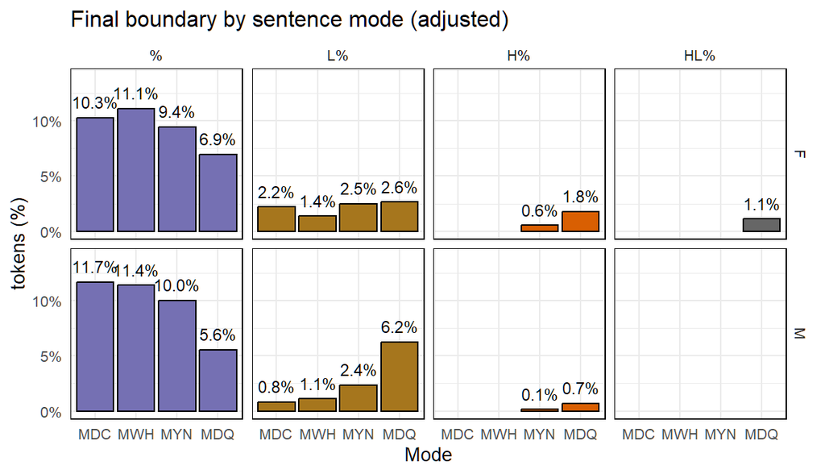

```r
my_plot <- ggplot(fin_phon_by_gender_adj_list) +
  geom_bar(
    mapping = aes(
      x = mode,
      y = (after_stat(count)) / sum(after_stat(count)),
      fill = fin_phon
    ),
    show.legend = F,
    colour = "black",
    position = position_dodge2(preserve = "single")
  ) +
  scale_y_continuous(labels = scales::percent, limits = c(0, 0.14)) +
  facet_grid(rows = vars(gender), cols = vars(fin_phon)) +
  ggtitle(
    "Final Boundary by Sentence Mode and Gender (Adjusted, No Register)"
  ) +
  theme(
    panel.border = element_rect(fill = NA)
  ) +
  ggtitle("Final boundary by sentence mode (adjusted)") +
  scale_fill_manual(values = fin_phon_colours, name = "nuclear contour") +
  labs(x = "Mode", y = "tokens (%)") +
  theme(panel.border = element_rect(fill = NA)) +
  geom_text(
    aes(
      x = mode,
      y = (after_stat(count)) / sum(after_stat(count)),
      label = percent((after_stat(count)) / sum(after_stat(count)), 1)
    ),
    stat = "count",
    vjust = -0.75,
    size = 3
  )

ggsave(
  filename =
    "output/fin_phon_by_mode_gender_non_reg.png",
  width = 15.5,
  plot = my_plot,
  height = 8.5,
  units = "cm",
  dpi = 300
)

my_plot
```

The results give the impression that this is a feature of male rather than female speech. However, only three out of the five male speakers do this, so it is unlikely to be a features of “male speech”. More likely, different speakers interpreted the motivation behind the prompt statement and their response, in terms of the intonational phonology, reflects whether or not they chose to use a surprise/redundancy falling boundary.

### BGLMM analysis

#### Likelihood of H%.

**Complete separation issue**

- GLMER cannot correctly estimate the CIs of H:L for MDC and MWH since there are no instances of H for either level, leading to a problem know as “complete separation”.

To resolve this issue, I have used the blme package, which uses “Maximum a posteriori estimation for linear and generalized linear mixed-effects models in a Bayesian setting” (documentation).

We can use this to “impose zero-mean Normal priors on the fixed effects (a 4 × 4 diagonal matrix with diagonal elements equal to 9, for variances of 9 or standard deviations of 3)”

(http://bbolker.github.io/mixedmodels-misc/ecostats_chap.html#digression-complete-separation)

(directed from https://bbolker.github.io/mixedmodels-misc/glmmFAQ.html#penalizationhandling-complete-separation)

```r
m_corpus_is_H_boundary <- m_corpus %>%
  ## treat HL% as for purpose of % vs H%
  mutate(`H%` = str_replace(fin_phon, "HL\\%", "H%")) %>%
  mutate(`H%` = factor(`H%` == "H%", level = c(F, T)))
```

```r
fin_phon_model_H_or_not <- bglmer(
  `H%` ~ mode + gender + (1 | speaker) + (1 | prompt),
  data = m_corpus_is_H_boundary,
  family = binomial(link = "logit"),
  fixef.prior = normal(),
  ## change optimizer to avoid convergence errors
  control = glmerControl(
    optimizer = "optimx",
    calc.derivs = FALSE,
    optCtrl = list(
      method = "nlminb",
      starttests = FALSE,
      kkt = FALSE
    )
  )
)

fin_phon_model_H_or_not <- optimizeModel(fin_phon_model_H_or_not, reject_nm = F)
```

##### LRT via drop1()

```r
write <- "output/Mode_fin_phon_no_Reg_0H"

model_formula <- getModelFormula(fin_phon_model_H_or_not)

write(
  paste(str_replace_all(model_formula, "\\`", ""), sep = ""),
  paste(write, "_formula.txt", sep = "")
)


## get, save, and print ANOVA of model
drop1_analysis <- drop1(fin_phon_model_H_or_not, test = "Chisq")

tibble(factor = row.names(drop1_analysis)) %>%
  cbind(tibble(drop1_analysis)) %>%
  filter(!is.na(npar)) %>%
  mutate(`p.adj (BH)` = NA, signif. = NA) %>%
  write_csv(paste0(write, "_anova.csv"))


adjustP_posthoc("output/",
  `Pr(Chi)`,
  suffix_id = "_anova"
)

read_csv(paste(write, "_anova.csv", sep = "")) %>%
  tidyStatNumbers() %>%
  formattable(caption = paste("Drop 1 ChiSq test of model:", model_formula))
```

Drop 1 ChiSq test of model: `H%` ~ mode + gender + (1 | speaker) + (1 | prompt)

| factor | npar | AIC | LRT | Pr(Chi) | p.adj (BH) | signif. |
| --- | --- | --- | --- | --- | --- | --- |
| mode | 3 | 223.2 | 65.02 | < .001 | < .001 | *p* < .05 |
| gender | 1 | 165.64 | 3.45 | .063 | .076 |  |

##### *R*<sup>2</sup> and prediction plots

Conditional and marginal R<sup>2</sup>

| marginal R<sup>2</sup> | conditional R<sup>2</sup> |
| --- | --- |
| .41 | .75 |

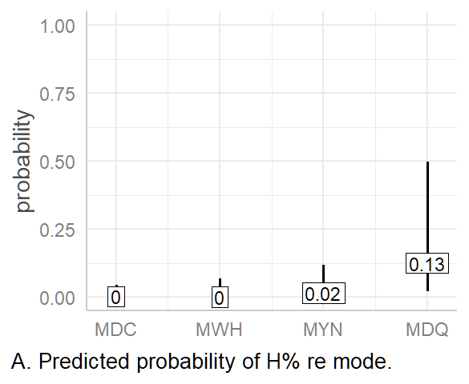

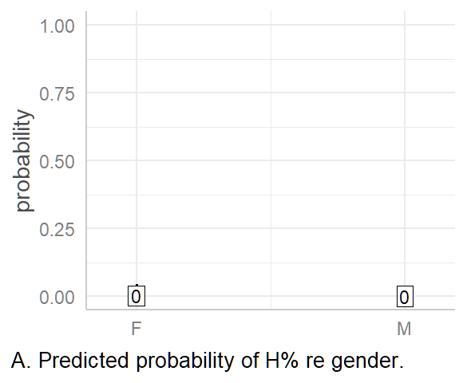

```r
tidy_summary <- analyseModel(
  fin_phon_model_H_or_not,
  write = write,
  is_GLM = T,
  type = "pred",
  plot_rounding = 2,
  short_caption = F,
  caption_prefix = "A. "
)
```

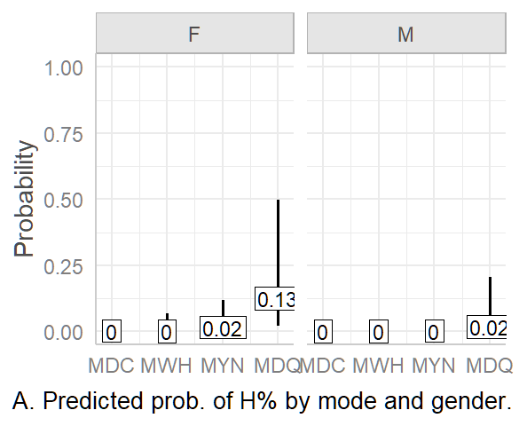

```r
my_plot <-
  ggpredict(fin_phon_model_H_or_not,
    terms = c("mode", "gender"),
    ci.lvl = 0.95
  ) %>%
  plot(grid = T, colors = "bw") +
  labs(caption = "A. Predicted prob. of H% by mode and gender.") +
  geom_label(
    aes(label = round(predicted, 2)),
    label.padding = unit(0.5, "mm"),
    label.r = unit(0.0, "mm"),
    size = 3
  ) +
  scale_y_continuous(limits = c(0, 1)) +
  ylab("Probability") +
  theme(
    plot.title = element_blank(),
    axis.title.x = element_blank(),
    plot.caption = element_text(hjust = 0, size = 10),
    plot.caption.position = "plot",
    legend.position = c(0.12, 0.8),
    legend.background = element_rect(colour = "darkGray")
  )

ggsave(
  filename =
    paste0(write, "_multi_pred.png"),
  plot = my_plot,
  ## width = 8.14,
  width = 14,
  height = 6.26,
  units = "cm",
  dpi = 300
)

print(my_plot)
```

##### Prediction tables

```r
printTidyPredictions(fin_phon_model_H_or_not,
  caption_suffix = " (no reg tier)",
  digits = 3
)
```

Predicted probabilities of H% (no reg tier)

| mode | predicted | conf.low | conf.high | std.error |
| --- | --- | --- | --- | --- |
| MDC | 0.002 | < 0.001 | 0.043 | 1.526 |
| MWH | < 0.001 | < 0.001 | 0.069 | 2.47 |
| MYN | 0.015 | 0.002 | 0.117 | 1.092 |
| MDQ | 0.125 | 0.02 | 0.496 | 0.984 |

Predicted probabilities of H% (no reg tier)

| gender | predicted | conf.low | conf.high | std.error |
| --- | --- | --- | --- | --- |
| F | 0.002 | < 0.001 | 0.043 | 1.526 |
| M | < 0.001 | < 0.001 | 0.01 | 1.782 |

##### Pairwise comparisons

```r
charts <- getModelFixedFX(
  fin_phon_model_H_or_not,
  write = write,
  exponentiate = T
)
```

`H%` ~ mode + gender + (1 | speaker) + (1 | prompt)

```r
# charts$intercepts
charts$slopes %>% tidyStatNumbers()
```

b1: H% ~ mode + gender + (1 | speaker) + (1 | prompt)

| intercept | slope | estimate | conf.low | conf.high | std.error | z.value | p.value |
| --- | --- | --- | --- | --- | --- | --- | --- |
| modeMDC | modeMWH | 0.26 | 0.00 | 38.50 | 0.66 | -0.53 | .597 |
| modeMDC | modeMYN | 6.88 | 0.56 | 84.00 | 8.78 | 1.51 | .131 |
| modeMDC | modeMDQ | 63.30 | 5.88 | 682.00 | 76.78 | 3.42 | < .001 |
| modeMWH | modeMYN | 6.87 | 0.56 | 84.00 | 8.78 | 1.51 | .131 |
| modeMWH | modeMDQ | 63.20 | 5.86 | 682.10 | 76.71 | 3.42 | < .001 |
| modeMYN | modeMDQ | 9.76 | 3.06 | 31.10 | 5.76 | 3.86 | < .001 |
| intercept | genderM | 0.14 | 0.01 | 2.46 | 0.2 | -1.35 | .177 |

##### Model printout

```r
summary(fin_phon_model_H_or_not)
```

```
## Cov prior  : speaker ~ wishart(df = 3.5, scale = Inf, posterior.scale = cov, common.scale = TRUE)
##            : prompt ~ wishart(df = 3.5, scale = Inf, posterior.scale = cov, common.scale = TRUE)
## Fixef prior: normal(sd = c(10, 2.5, ...), corr = c(0 ...), common.scale = FALSE)
## Prior dev  : 24.292
##
## Generalized linear mixed model fit by maximum likelihood (Laplace
##   Approximation) [bglmerMod]
##  Family: binomial  ( logit )
## Formula: `H%` ~ mode + gender + (1 | speaker) + (1 | prompt)
##    Data: m_corpus_is_H_boundary
## Control:
## glmerControl(optimizer = "optimx", calc.derivs = FALSE, optCtrl = list(method = "nlminb",
##     starttests = FALSE, kkt = FALSE))
##
##      AIC      BIC   logLik deviance df.resid
##    164.2    195.4    -75.1    150.2      632
##
## Scaled residuals:
##     Min      1Q  Median      3Q     Max
## -1.4111 -0.1227 -0.0412 -0.0180  4.7220
##
## Random effects:
##  Groups  Name        Variance Std.Dev.
##  speaker (Intercept) 3.7152   1.9275
##  prompt  (Intercept) 0.7351   0.8574
## Number of obs: 639, groups:  speaker, 11; prompt, 3
##
## Fixed effects:
##             Estimate Std. Error z value Pr(>|z|)
## (Intercept)   -6.093      1.526  -3.993 6.52e-05 ***
## modeMWH       -1.349      2.552  -0.529 0.596977
## modeMYN        1.929      1.276   1.511 0.130706
## modeMDQ        4.148      1.213   3.420 0.000626 ***
## genderM       -2.037      1.497  -1.360 0.173819
## ---
## Signif. codes:  0 '***' 0.001 '**' 0.01 '*' 0.05 '.' 0.1 ' ' 1
##
## Correlation of Fixed Effects:
##         (Intr) modMWH modMYN modMDQ
## modeMWH -0.352
## modeMYN -0.710  0.421
## modeMDQ -0.765  0.443  0.891
## genderM -0.305  0.000 -0.003 -0.008
```

```r
cat(
  "isSingular(fin_phon_model_H_or_not, tol=1e-5) -->",
  isSingular(fin_phon_model_H_or_not, tol = 1e-5),
  "\n"
)
```

```
## isSingular(fin_phon_model_H_or_not, tol=1e-5) --> FALSE
```

## 7.5.2 Register-tier Analysis

### Raw Data

#### Contour by sentence mode

```r
m_corpus %>%
  group_by(mode, nuc_contour) %>%
  summarise(acc_count = n(), .groups = "keep") %>%
  pivot_wider(
    names_from = nuc_contour,
    values_from = acc_count,
    values_fill = 0
  ) %>%
  adorn_totals(where = "row") %>%
  select(
    c(
      "mode",
      "H* L%",
      ">H* L%",
      "^[L*]H L%",
      "L*H %",
      "L*H L%",
      "L*^[H] %",
      "L*^[H L%]",
      "L*^[H] L%",
      "^[L*H] %",
      "^[L*H L%]",
      "^[L*H] L%"
    )
  ) %>%
  rename_all(list(~ str_replace_all(., "([\\*\\[\\^\\>])", "\\\\\\1"))) %>%
  formattable(
    align = c("l", rep("r", ncol(.) - 1)),
    caption = "Nuclear contours by mode in M-corpus (raw)"
  )
```

Nuclear contours by mode in M-corpus (raw)

| mode | H* L% | >H* L% | ^[L*]H L% | L*H % | L*H L% | L*^[H] % | L*^[H L%] | L*^[H] L% | ^[L*H] % | ^[L*H L%] | ^[L*H] L% |
| --- | --- | --- | --- | --- | --- | --- | --- | --- | --- | --- | --- |
| MDC | 2 | 2 | 0 | 141 | 18 | 0 | 0 | 0 | 0 | 0 | 0 |
| MWH | 0 | 0 | 0 | 144 | 17 | 0 | 0 | 0 | 0 | 0 | 0 |
| MYN | 0 | 2 | 3 | 97 | 18 | 5 | 0 | 0 | 30 | 6 | 1 |
| MDQ | 0 | 1 | 3 | 37 | 6 | 17 | 6 | 2 | 51 | 12 | 18 |
| Total | 2 | 5 | 6 | 419 | 59 | 22 | 6 | 2 | 81 | 18 | 19 |

#### Pitch accents by speaker

```r
## Create summary table of Pitch Accent by Speaker.


m_corpus %>%
  group_by(speaker, acc_phon) %>%
  summarise(acc_count = n(), .groups = "keep") %>%
  pivot_wider(
    names_from = acc_phon,
    values_from = acc_count,
    values_fill = 0
  ) %>%
  select("speaker", "H*", "^[L*]H", ">H*", "L*H", "L*^[H]", "^[L*H]") %>%
  rename_all(list(~ str_replace_all(., "([\\*\\[\\^\\>])", "\\\\\\1"))) %>%
  adorn_totals(where = "row") %>%
  formattable(
    align = c("l", rep("r", ncol(.) - 1)),
    caption =
      "distribution by speaker of nuclear pitch accents in M-corpus (raw)",
    list(area(col = 2:7, row = 1:nrow(.) - 1) ~ proportion_bar(color = c(
      rep(brewer.pal(6, "Pastel2")[1], nrow(.) - 1),
      rep(brewer.pal(6, "Pastel2")[5], nrow(.) - 1),
      rep(brewer.pal(6, "Pastel2")[4], nrow(.) - 1),
      rep(brewer.pal(6, "Pastel2")[3], nrow(.) - 1),
      rep(brewer.pal(6, "Pastel2")[2], nrow(.) - 1),
      rep(brewer.pal(6, "Pastel2")[6], nrow(.) - 1)
    )))
  )
```

distribution by speaker of nuclear pitch accents in M-corpus (raw)

| speaker | H* | ^[L*]H | >H* | L*H | L*^[H] | ^[L*H] |
| --- | --- | --- | --- | --- | --- | --- |
| F5 | 0 | 0 | 0 | 45 | 13 | 1 |
| F6 | 0 | 0 | 0 | 51 | 5 | 4 |
| F12 | 0 | 0 | 0 | 45 | 1 | 14 |
| F15 | 0 | 0 | 0 | 51 | 4 | 5 |
| F16 | 0 | 0 | 0 | 59 | 1 | 0 |
| F17 | 0 | 0 | 0 | 47 | 1 | 7 |
| M4 | 0 | 0 | 0 | 36 | 5 | 16 |
| M5 | 0 | 0 | 0 | 36 | 0 | 24 |
| M8 | 2 | 6 | 5 | 29 | 0 | 19 |
| M9 | 0 | 0 | 0 | 40 | 0 | 7 |
| M10 | 0 | 0 | 0 | 52 | 0 | 8 |
| Total | 2 | 6 | 5 | 491 | 30 | 105 |

#### All pitch contours

```r
## Create summary table of Pitch Accent by Speaker.
m_corpus %>%
  group_by(nuc_contour) %>%
  summarise(nuc_count = n(), .groups = "keep") %>%
  mutate(nuc_contour = str_replace_all(
    nuc_contour, "([\\*\\[\\^\\>])", "\\\\\\1"
  )) %>%
  rename(
    `nuclear contour` = nuc_contour,
    `count` = nuc_count
  ) %>%
  arrange(desc(`count`)) %>%
  kable(caption = "Nuclear pitch contours (raw data)")
```

Nuclear pitch contours (raw data)

| nuclear contour | count |
| --- | --- |
| L*H % | 419 |
| ^[L*H] % | 81 |
| L*H L% | 59 |
| L*^[H] % | 22 |
| ^[L*H] L% | 19 |
| ^[L*H L%] | 18 |
| ^[L*]H L% | 6 |
| L*^[H L%] | 6 |
| &gt;H* L% | 5 |
| H* L% | 2 |
| L*^[H] L% | 2 |

### Adjusted Data

The raw data is unbalanced since the number of utterances per target speaker varies slightly. For some speakers, there are no repetitions of some target utterances. Therefore, the data has been adjusted to project an estimated balanced number of tokens per speaker per target utterance.

Firstly a tibble is created summarising the proportion of pitch accents per mode per speaker. This is done in three initial stages:

1. Count the number of phonological tokens per stimulus per speaker.
2. Convert the counts to proportion per stimulus per speaker.
3. Convert the proportion per stimulus per speaker to a proportion per stimulus per mode.

From this table summary tables are created:

1. pitch accents per speaker (adjusted)
   1. Calculate the sum all proportions per token per speaker.
   2. Convert proportions to an integer based on an ideal total number of tokens per speaker.
2. pitch accents per mode (adjusted):
   1. Calculate the sum all proportions per token per mode.
   2. Convert proportions to an integer based on an ideal total number of tokens per mode
3. pitch accents by gender and mode (adjusted):
   1. Calculate the sum all proportions per token by mode and gender.
2. Convert proportions to an integer based on an ideal total number of tokens per mode as if there were an equal numnber of male and female participants.

```r
## Create tibble summarising  proportion of pitch accents per mode per speaker
##
pa_adj <- m_corpus %>%
  ## Count the number of acc_phon by speaker and mode
  group_by(speaker, stim, acc_phon) %>%
  summarise(nuc_count = n(), .groups = "keep") %>%
  pivot_wider(names_from = acc_phon, values_from = nuc_count, values_fill = 0) %>%
  ## convert the totals to proportion per stim.
  adorn_totals("col") %>%
  mutate(across(3:8, ~ (. / Total))) %>%
  select(-Total) %>%
  ## Convert stim column to mode.
  rename(mode = stim) %>%
  mutate(mode = substr(mode, 1, 3)) %>%
  ## Convert the values to proportion per mode
  pivot_longer(3:last_col(), names_to = "acc_phon") %>%
  group_by(speaker, mode, acc_phon) %>%
  pivot_wider(
    names_from = acc_phon,
    values_from = value,
    values_fill = 0,
    values_fn = ~ sum(.)
  ) %>%
  adorn_totals("col") %>%
  mutate(across(3:8, ~ (. / Total)),
    mode = factor(mode, levels = c("MDC", "MWH", "MYN", "MDQ"))
  ) %>%
  select(-Total) %>%
  as_tibble()


## Create tibble of pitch accents per speaker (adjusted).
##
pa_by_speaker_adj <- pa_adj %>%
  ## Get the sum of all token proportions per speaker.
  pivot_longer(3:last_col(), names_to = "acc_phon") %>%
  select(-mode) %>%
  pivot_wider(
    names_from = acc_phon,
    values_from = value,
    values_fill = 0,
    values_fn = ~ sum(.)
  ) %>%
  ## Convert proportions to an integer based on an ideal total number of tokens
  ## per speaker.
  mutate(across(2:7, ~ round(. * 15, 0))) %>%
  select("speaker", "H*", ">H*", "^[L*]H", "L*H", "L*^[H]", "^[L*H]")


## Create tibble of pitch accents per mode (adjusted).
##
pa_by_mode_adj <- pa_adj %>%
  ## Get the sum of all token proportions per speaker.
  pivot_longer(3:last_col(), names_to = "acc_phon") %>%
  select(-speaker) %>%
  pivot_wider(
    names_from = acc_phon,
    values_from = value,
    values_fill = 0,
    values_fn = ~ sum(.)
  ) %>%
  ## Convert proportions to an integer based on an ideal total number of tokens.
  mutate(across(2:7, ~ round(. * 15, 0))) %>%
  select("mode", "H*", ">H*", "^[L*]H", "L*H", "L*^[H]", "^[L*H]") %>%
  arrange(mode)


## Create tibble of pitch accents by gender and mode (adjusted).
##
pa_by_gender_adj <- pa_adj %>%
  ## Convert gender to speaker
  mutate(
    speaker = substr(speaker, 1, 1),
    speaker = factor(speaker, levels = unique(speaker))
  ) %>%
  rename(gender = speaker) %>%
  ## Get the sum of all token proportions per speaker.
  pivot_longer(3:last_col(), names_to = "acc_phon") %>%
  pivot_wider(
    names_from = acc_phon,
    values_from = value,
    values_fill = 0,
    values_fn = ~ sum(.)
  ) %>%
  ## Convert proportions to an integer based on an ideal total number of tokens
  ## per speaker.
  mutate(across(3:8, ~ if_else(gender == "F",
    round(. * 15, 0),
    ## project equal number of Male & Female speakers.
    round(. * 18, 0)
  ))) %>%
  select("mode", "gender", "H*", ">H*", "^[L*]H", "L*H", "L*^[H]", "^[L*H]") %>%
  arrange(mode)


## Create tibble of pitch accents by gender and mode (adjusted).
##
pa_by_mode_speaker_adj <- pa_adj %>%
  ## Get the sum of all token proportions per speaker.
  pivot_longer(3:last_col(), names_to = "acc_phon") %>%
  pivot_wider(
    names_from = acc_phon,
    values_from = value,
    values_fill = 0,
    values_fn = ~ sum(.)
  ) %>%
  ## Convert proportions to integer based on ideal number of by-speaker tokens.
  mutate(across(3:last_col(), ~ round(. * 16))) %>%
  ## re-order the columns
  select("mode", "speaker", "H*", ">H*", "^[L*]H", "L*H", "L*^[H]", "^[L*H]") %>%
  arrange(speaker)
```

#### Nuclear PA Tables

##### by mode (common)

```r
pa_by_mode_adj %>%
  select("mode", "L*H", "L*^[H]", "^[L*H]") %>%
  rename_all(list(~ str_replace_all(., "([\\*\\[\\^\\>])", "\\\\\\1"))) %>%
  adorn_totals("row") %>%
  formattable(
    align = c("l", rep("r", ncol(.) - 1)),
    caption = paste(
      "distribution by of pitch accents by mode in M-corpus",
      "(adjusted, outliers excluded)"
    ),
    list(area(col = 2:4, row = 1:nrow(.) - 1) ~ proportion_bar(color = c(
      rep(brewer.pal(6, "Pastel2")[3], 4),
      rep(brewer.pal(6, "Pastel2")[2], 4),
      rep(brewer.pal(6, "Pastel2")[6], 4)
    )))
  )
```

distribution by of pitch accents by mode in M-corpus (adjusted, outliers excluded)

| mode | L*H | L*^[H] | ^[L*H] |
| --- | --- | --- | --- |
| MDC | 162 | 0 | 0 |
| MWH | 165 | 0 | 0 |
| MYN | 117 | 5 | 38 |
| MDQ | 62 | 25 | 74 |
| Total | 506 | 30 | 112 |

##### by mode (all)

```r
## Calculate a projected balanced number of tokens for each PA as a function of ## sentence mode.
#
## This takes into consideration the number of utterances per speaker per stimulus and the number of speakers per stimulus.

pa_by_mode_adj %>%
  rename_all(list(~ str_replace_all(., "([\\*\\[\\^\\>])", "\\\\\\1"))) %>%
  adorn_totals("row") %>%
  formattable(
    align = c("l", rep("r", ncol(.) - 1)),
    caption =
      "distribution by mode of nuclear pitch accents in M-corpus (adjusted)",
    list(area(col = 2:7, row = 1:4) ~ proportion_bar(color = c(
      rep(brewer.pal(6, "Pastel2")[1], nrow(.) - 1),
      rep(brewer.pal(6, "Pastel2")[4], nrow(.) - 1),
      rep(brewer.pal(6, "Pastel2")[5], nrow(.) - 1),
      rep(brewer.pal(6, "Pastel2")[3], nrow(.) - 1),
      rep(brewer.pal(6, "Pastel2")[2], nrow(.) - 1),
      rep(brewer.pal(6, "Pastel2")[6], nrow(.) - 1)
    )))
  )
```

distribution by mode of nuclear pitch accents in M-corpus (adjusted)

| mode | H* | >H* | ^[L*]H | L*H | L*^[H] | ^[L*H] |
| --- | --- | --- | --- | --- | --- | --- |
| MDC | 2 | 2 | 0 | 162 | 0 | 0 |
| MWH | 0 | 0 | 0 | 165 | 0 | 0 |
| MYN | 0 | 2 | 3 | 117 | 5 | 38 |
| MDQ | 0 | 1 | 3 | 62 | 25 | 74 |
| Total | 2 | 5 | 6 | 506 | 30 | 112 |

##### by speaker

```r
pa_by_speaker_adj %>%
  rename_all(list(~ str_replace_all(., "([\\*\\[\\^\\>])", "\\\\\\1"))) %>%
  adorn_totals(where = "row") %>%
  formattable(
    align = c("l", rep("r", ncol(.) - 1)),
    caption = "distribution by speaker of nuclear pitch accents in M-corpus (adjusted)",
    list(area(col = 2:7, row = 1:nrow(.) - 1) ~ proportion_bar(color = c(
      rep(brewer.pal(6, "Pastel2")[1], nrow(.) - 1),
      rep(brewer.pal(6, "Pastel2")[4], nrow(.) - 1),
      rep(brewer.pal(6, "Pastel2")[5], nrow(.) - 1),
      rep(brewer.pal(6, "Pastel2")[3], nrow(.) - 1),
      rep(brewer.pal(6, "Pastel2")[2], nrow(.) - 1),
      rep(brewer.pal(6, "Pastel2")[6], nrow(.) - 1)
    )))
  )
```

distribution by speaker of nuclear pitch accents in M-corpus (adjusted)

| speaker | H* | >H* | ^[L*]H | L*H | L*^[H] | ^[L*H] |
| --- | --- | --- | --- | --- | --- | --- |
| F5 | 0 | 0 | 0 | 46 | 13 | 1 |
| F6 | 0 | 0 | 0 | 51 | 5 | 4 |
| F12 | 0 | 0 | 0 | 45 | 1 | 14 |
| F15 | 0 | 0 | 0 | 51 | 4 | 5 |
| F16 | 0 | 0 | 0 | 59 | 1 | 0 |
| F17 | 0 | 0 | 0 | 52 | 1 | 7 |
| M4 | 0 | 0 | 0 | 36 | 5 | 19 |
| M5 | 0 | 0 | 0 | 36 | 0 | 24 |
| M8 | 2 | 5 | 6 | 29 | 0 | 19 |
| M9 | 0 | 0 | 0 | 49 | 0 | 11 |
| M10 | 0 | 0 | 0 | 52 | 0 | 8 |
| Total | 2 | 5 | 6 | 506 | 30 | 112 |

#### Nuclear PA Figures

##### by speaker (chart)

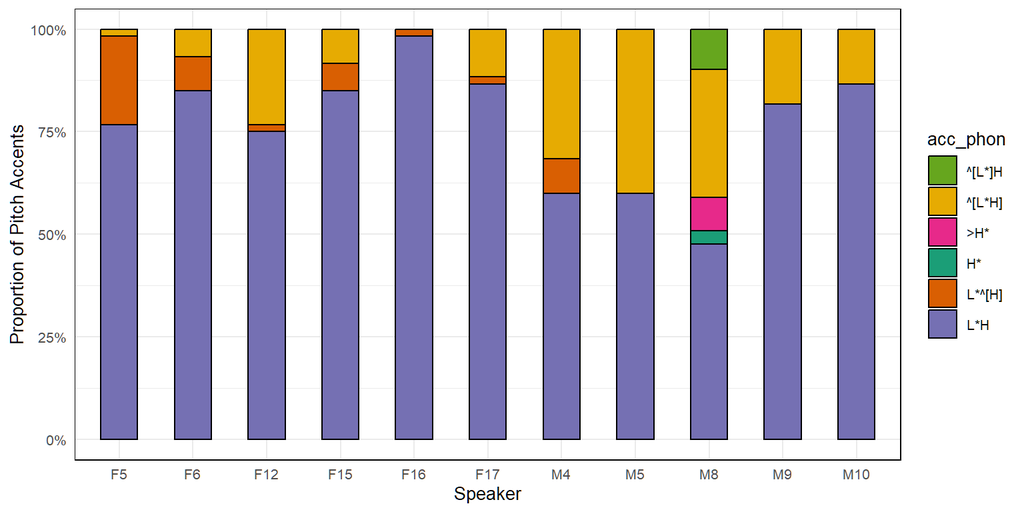

```r
## Percentage Stacked bar
ggplot(
  data = pa_by_speaker_adj %>%
    ## uncount data for plotting
    gather("acc_phon", "count", -c(speaker)) %>%
    uncount(count),
  aes(fill = acc_phon, x = speaker)
) +
  geom_bar(
    stat = "count",
    position = "fill",
    width = 0.50,
    colour = "black"
  ) +
  scale_y_continuous(labels = scales::label_percent(scale = 100)) +
  scale_fill_manual(values = pitch_accent_colours[1:6]) +
  labs(
    y = "Proportion of Pitch Accents",
    x = "Speaker"
  ) +
  theme(panel.border = element_rect(fill = NA))
```

##### by mode (common)

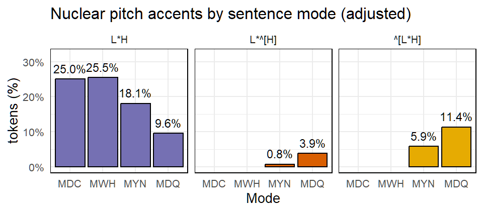

```r
ggplot(pa_by_mode_adj %>%
  ## uncount table for bar chart
  pivot_longer(2:last_col(), names_to = "acc_phon") %>%
  uncount(value) %>%
  ## exclude outliers.
  filter(acc_phon %in% c("L*H", "L*^[H]", "^[L*H]")) %>%
  mutate(acc_phon = factor(acc_phon,
    levels = c("L*H", "L*^[H]", "^[L*H]")
  ))) +
  geom_bar(
    mapping = aes(
      x = mode,
      y = (..count..) / sum(..count..),
      fill = acc_phon
    ),
    show.legend = F,
    colour = "black",
    position = position_dodge2(preserve = "single")
  ) +
  scale_y_continuous(labels = scales::percent, limits = c(0, 0.32)) +
  facet_grid(cols = vars(acc_phon)) +
  theme(panel.border = element_rect(fill = NA)) +
  ggtitle("Nuclear pitch accents by sentence mode (adjusted)") +
  scale_fill_manual(values = pitch_accent_colours, name = "Pitch Accent") +
  labs(x = "Mode", y = "tokens (%)") +
  theme(panel.border = element_rect(fill = NA)) +
  geom_text(
    aes(
      x = mode,
      y = (..count..) / sum(..count..),
      label = percent((..count..) / sum(..count..), 1)
    ),
    stat = "count",
    vjust = -0.7,
    size = 3
  )
```

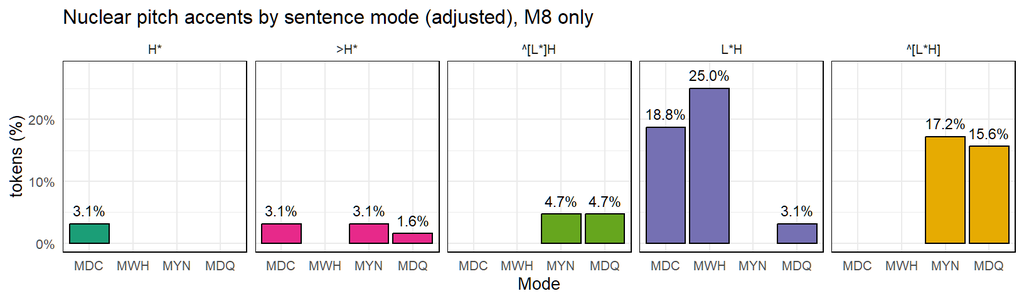

```r
ggplot(
  pa_by_mode_speaker_adj %>%
    filter(speaker == "M8") %>%
    ## Uncount tables bar chart.
    pivot_longer(3:last_col(), names_to = "acc_phon") %>%
    uncount(value) %>%
    mutate(acc_phon = factor(
      acc_phon,
      levels = c("H*", ">H*", "^[L*]H", "L*H", "L*^[H]", "^[L*H]")
    ))
) +
  geom_bar(
    mapping = aes(
      x = mode,
      y = (..count..) / sum(..count..),
      fill = acc_phon
    ),
    show.legend = F,
    colour = "black",
    position = position_dodge2(preserve = "single")
  ) +
  scale_y_continuous(labels = scales::percent, limits = c(0, 0.28)) +
  facet_grid(cols = vars(acc_phon)) +
  ggtitle("Nuclear pitch accents by sentence mode (adjusted), M8 only") +
  theme(
    panel.border = element_rect(fill = NA)
  ) +
  scale_fill_manual(values = pitch_accent_colours, name = "Pitch Accent") +
  labs(x = "Mode", y = "tokens (%)") +
  theme(panel.border = element_rect(fill = NA)) +
  geom_text(
    aes(
      x = mode,
      y = (..count..) / sum(..count..),
      label = percent((..count..) / sum(..count..), 1)
    ),
    stat = "count",
    vjust = -0.7,
    size = 3
  )
```

##### by mode and gender (common)

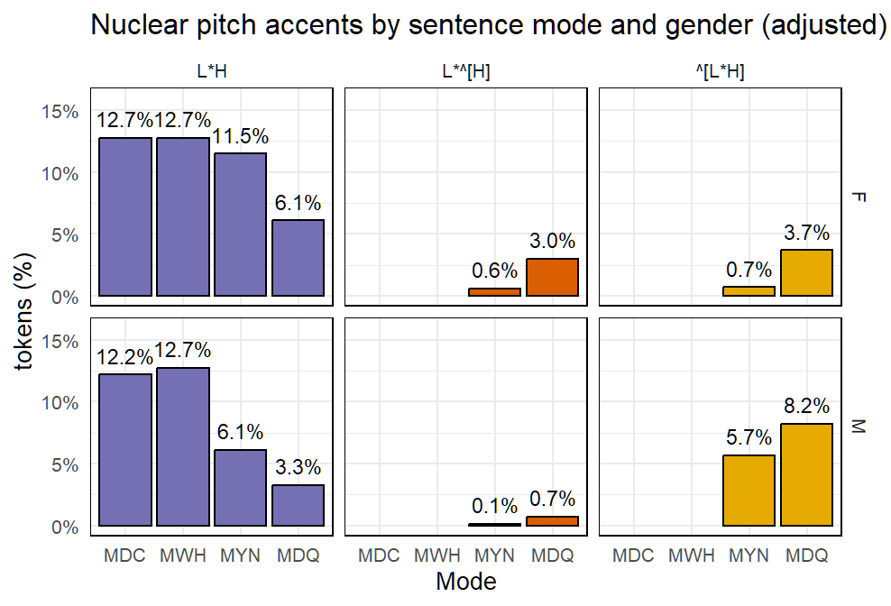

```r
ggplot(pa_by_gender_adj %>%
  ## Uncount tables bar chart.
  pivot_longer(3:last_col(), names_to = "acc_phon") %>%
  uncount(value) %>%
  ## Exclude outliers.
  filter(acc_phon %in% c("L*H", "L*^[H]", "^[L*H]")) %>%
  mutate(acc_phon = factor(acc_phon, levels = c("L*H", "L*^[H]", "^[L*H]")))) +
  geom_bar(
    mapping = aes(
      x = mode,
      y = (..count..) / sum(..count..),
      fill = acc_phon
    ),
    show.legend = F,
    colour = "black",
    position = position_dodge2(preserve = "single")
  ) +
  scale_y_continuous(labels = scales::percent, limits = c(0, 0.16)) +
  facet_grid(rows = vars(gender), cols = vars(acc_phon)) +
  ggtitle("Nuclear pitch accents by sentence mode and gender (adjusted)") +
  theme(
    panel.border = element_rect(fill = NA)
  ) +
  scale_fill_manual(values = pitch_accent_colours, name = "Pitch Accent") +
  labs(x = "Mode", y = "tokens (%)") +
  theme(panel.border = element_rect(fill = NA)) +
  geom_text(
    aes(
      x = mode,
      y = (..count..) / sum(..count..),
      label = percent((..count..) / sum(..count..), 1)
    ),
    stat = "count",
    vjust = -0.7,
    size = 3
  )
```

##### by mode and speaker (all)

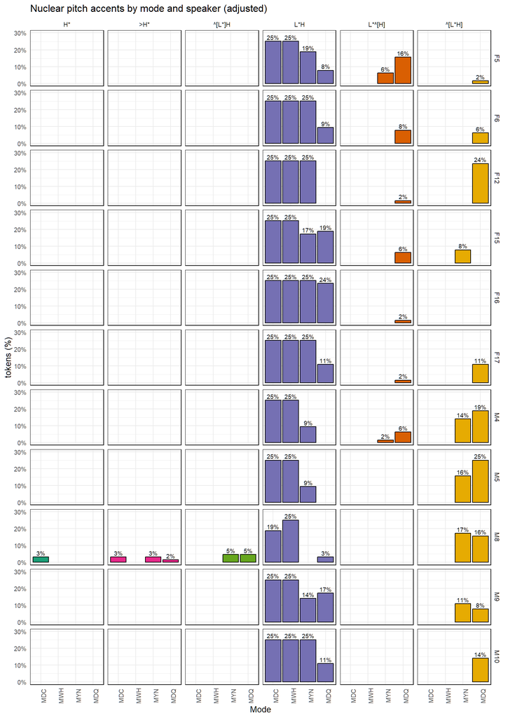

```r
ggplot(
  pa_by_mode_speaker_adj %>%
    ## Uncount tables bar chart.
    pivot_longer(3:last_col(), names_to = "acc_phon") %>%
    uncount(value) %>%
    mutate(acc_phon = factor(
      acc_phon,
      levels = c("H*", ">H*", "^[L*]H", "L*H", "L*^[H]", "^[L*H]")
    ))
) +
  geom_bar(
    mapping = aes(
      x = mode,
      y = 11 * (..count..) / sum(..count..),
      fill = acc_phon
    ),
    show.legend = F,
    colour = "black",
    position = position_dodge2(preserve = "single")
  ) +
  geom_text(
    aes(
      x = mode,
      y = 11 * (..count..) / sum(..count..),
      label = 11 * percent((..count..) / sum(..count..), 0)
    ),
    stat = "count",
    vjust = -0.35,
    size = 2.5
  ) +
  scale_y_continuous(labels = scales::percent, limits = c(0, 0.30)) +
  facet_grid(rows = vars(speaker), cols = vars(acc_phon)) +
  ggtitle("Nuclear pitch accents by mode and speaker (adjusted)") +
  theme(
    panel.border = element_rect(fill = NA),
    axis.text.x = element_text(angle = 90, size = 7.5),
    axis.text.y = element_text(size = 7.5),
    # axis.text.x = element_text(, vjust = 0.5, hjust=1)
  ) +
  scale_fill_manual(values = pitch_accent_colours, name = "Pitch Accent") +
  labs(x = "Mode", y = "tokens (%)") +
  theme(panel.border = element_rect(fill = NA))
```

```r
ggsave(
  filename =
    "output/nuc_PA_by_mode_and_speaker.png",
  width = 15.45,
  height = 24,
  units = "cm",
  dpi = 300
)
```

### Boundary Tone Analysis

```r
fin_phon_adj <- m_corpus %>%
  mutate(fin_phon = str_replace_all(fin_phon, "\\[|\\]|\\^", "")) %>%
  mutate(fin_phon = factor(fin_phon, levels = unique(fin_phon))) %>%
  ## Count the number of fin_phon by speaker and mode
  group_by(speaker, stim, fin_phon) %>%
  summarise(nuc_count = n(), .groups = "keep") %>%
  pivot_wider(
    names_from = fin_phon,
    values_from = nuc_count,
    values_fill = 0
  ) %>%
  ## convert the totals to proportion per stim.
  adorn_totals("col") %>%
  mutate(across(3:(last_col() - 1), ~ (. / Total))) %>%
  select(-Total) %>%
  ## Convert stim column to mode.
  rename(mode = stim) %>%
  mutate(mode = substr(mode, 1, 3)) %>%
  ## Convert the values to proportion per mode
  pivot_longer(3:last_col(), names_to = "fin_phon") %>%
  group_by(speaker, mode, fin_phon) %>%
  pivot_wider(
    names_from = fin_phon,
    values_from = value,
    values_fill = 0,
    values_fn = ~ sum(.)
  ) %>%
  adorn_totals("col") %>%
  mutate(across(3:(last_col() - 1), ~ (. / Total)),
    mode = factor(mode, levels = c("MDC", "MWH", "MYN", "MDQ"))
  ) %>%
  select(-Total) %>%
  as_tibble()

## Create tibble of final boundaries per mode (adjusted).
fin_phon_by_mode_adj <- fin_phon_adj %>%
  ## Get the sum of all token proportions per speaker.
  pivot_longer(3:last_col(), names_to = "fin_phon") %>%
  select(-c(speaker)) %>%
  pivot_wider(
    names_from = fin_phon,
    values_from = value,
    values_fill = 0,
    values_fn = ~ sum(.)
  ) %>%
  ## Convert proportions to an integer based on an ideal total number of tokens.
  mutate(across(2:last_col(), ~ round(. * 15, 0))) %>%
  arrange(mode)

## Create tibble of final boundaries  by gender and mode (adjusted).
fin_phon_by_gender_adj <- fin_phon_adj %>%
  ## Convert speaker to gender
  mutate(
    speaker = substr(speaker, 1, 1),
    speaker = factor(speaker, levels = unique(speaker))
  ) %>%
  rename(gender = speaker) %>%
  ## Get the sum of all token proportions per speaker.
  pivot_longer(3:last_col(), names_to = "fin_phon") %>%
  pivot_wider(
    names_from = fin_phon,
    values_from = value,
    values_fill = 0,
    values_fn = ~ sum(.)
  ) %>%
  ## Convert proportions to an integer based on an ideal total number of tokens
  ## per speaker.
  mutate(across(3:last_col(), ~ if_else(gender == "F",
    round(. * 15, 0),
    ## project equal number of Male & Female speakers.
    round(. * 18, 0)
  ))) %>%
  arrange(mode)

## Make lists of projected boundary tokens.
fin_phon_by_mode_adj_list <- fin_phon_by_mode_adj %>%
  pivot_longer(2:last_col(), names_to = "fin_phon") %>%
  uncount(value) %>%
  mutate(fin_phon = factor(fin_phon, levels = unique(fin_phon)))


## Get list of projected boundary tokens by mode and gender.
fin_phon_by_gender_adj_list <- fin_phon_by_gender_adj %>%
  pivot_longer(3:last_col(), names_to = "fin_phon") %>%
  uncount(value) %>%
  mutate(fin_phon = factor(fin_phon, levels = unique(fin_phon)))
```

#### by sentence mode

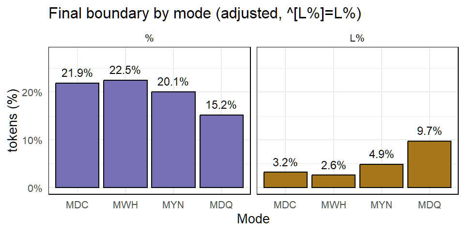

```r
ggplot(fin_phon_by_mode_adj_list) +
  geom_bar(
    mapping = aes(
      x = mode,
      y = (..count..) / sum(..count..),
      fill = fin_phon
    ),
    show.legend = F,
    colour = "black",
    position = position_dodge2(preserve = "single")
  ) +
  scale_y_continuous(labels = scales::percent, limits = c(0, 0.28)) +
  facet_grid(cols = vars(fin_phon)) +
  theme(
    panel.border = element_rect(fill = NA)
  ) +
  ggtitle("Final boundary by mode (adjusted, ^[L%]=L%)") +
  scale_fill_manual(values = fin_phon_colours, name = "final boundary") +
  labs(x = "Mode", y = "tokens (%)") +
  theme(panel.border = element_rect(fill = NA)) +
  geom_text(
    aes(
      x = mode,
      y = (..count..) / sum(..count..),
      label = percent((..count..) / sum(..count..), 1)
    ),
    stat = "count",
    vjust = -0.75,
    size = 3
  )
```

#### by sentence mode and gender

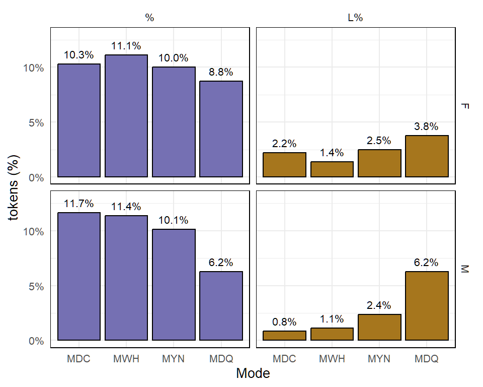

```r
ggplot(fin_phon_by_gender_adj_list) +
  geom_bar(
    mapping = aes(
      x = mode,
      y = (..count..) / sum(..count..),
      fill = fin_phon
    ),
    show.legend = F,
    colour = "black",
    position = position_dodge2(preserve = "single")
  ) +
  scale_y_continuous(labels = scales::percent, limits = c(0, 0.13)) +
  facet_grid(rows = vars(gender), cols = vars(fin_phon)) +
  theme(
    panel.border = element_rect(fill = NA)
  ) +
  ggtitle("Final boundary by mode and gender") +
  scale_fill_manual(values = fin_phon_colours, name = "nuclear contour") +
  labs(x = "Mode", y = "tokens (%)") +
  theme(
    panel.border = element_rect(fill = NA),
    plot.title = element_blank()
  ) +
  geom_text(
    aes(
      x = mode,
      y = (..count..) / sum(..count..),
      label = percent((..count..) / sum(..count..), 1)
    ),
    stat = "count",
    vjust = -0.75,
    size = 2.75
  )
```

```r
ggsave(
  filename =
    "output/fin_phon_reg_tier.png",
  width = 8.5,
  height = 8,
  units = "cm",
  dpi = 300
)
```

### BGLMM Analysis

#### H-Register and Mode

```r
m_corpus_h_reg <- m_corpus %>%
  select(prompt, speaker, gender, nuc_H_reg, mode)


h_reg_model <- bglmer(
  nuc_H_reg ~ mode + gender + (1 | speaker) + (1 | prompt),
  data = m_corpus_h_reg,
  family = binomial(link = "logit"),
  fixef.prior = normal()
)


h_reg_model <- optimizeModel(h_reg_model, reject_nm = F)
```

##### LRT

```r
write <- "output/Mode_PA_GLMM"

model_formula <- getModelFormula(h_reg_model)

write(
  paste(str_replace_all(model_formula, "\\`", ""), sep = ""),
  paste(write, "_formula.txt", sep = "")
)


## get, save, and print ANOVA of model
drop1_analysis <- drop1(h_reg_model, test = "Chisq") %>%
  tidy() %>%
  filter(!is.na(npar)) %>%
  mutate(`p.adj (BH)` = NA, signif. = NA) %>%
  rename(factor = term) %>%
  rename(`Pr(Chi)` = Pr.Chi.) %>%
  write_csv(paste0(write, "_anova.csv"))


adjustP_posthoc("output/",
  `Pr(Chi)`,
  suffix_id = "_anova"
)

read_csv(paste(write, "_anova.csv", sep = "")) %>%
  tidyStatNumbers() %>%
  formattable(caption = paste("Drop 1 ChiSq test of model:", model_formula))
```

Drop 1 ChiSq test of model: nuc_H_reg ~ mode + gender + (1 | speaker) + (1 | prompt)

| factor | npar | AIC | LRT | Pr(Chi) | p.adj (BH) | signif. |
| --- | --- | --- | --- | --- | --- | --- |
| mode | 3 | 652.71 | 320.5 | < .001 | < .001 | *p* < .05 |
| gender | 1 | 341.59 | 5.38 | .02 | .027 | *p* < .05 |

##### *R*<sup>2</sup> and prediction plots

Conditional and marginal R<sup>2</sup>

| marginal R<sup>2</sup> | conditional R<sup>2</sup> |
| --- | --- |
| .69 | .79 |

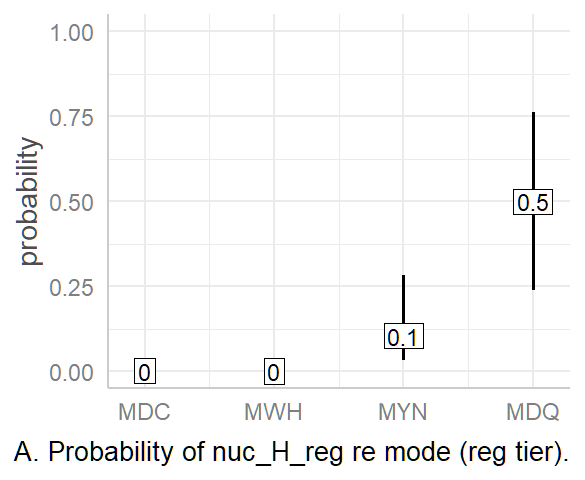

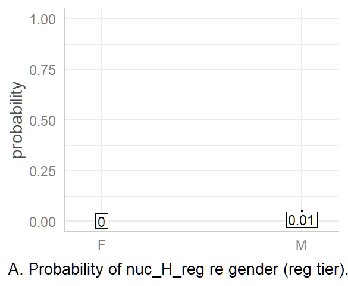

```r
tidy_summary <- analyseModel(
  h_reg_model,
  write = write,
  is_GLM = T,
  type = "pred",
  caption_suffix = " (reg tier)",
  plot_rounding = 2,
  short_caption = T,
  caption_prefix = "A. Probability of"
)
```

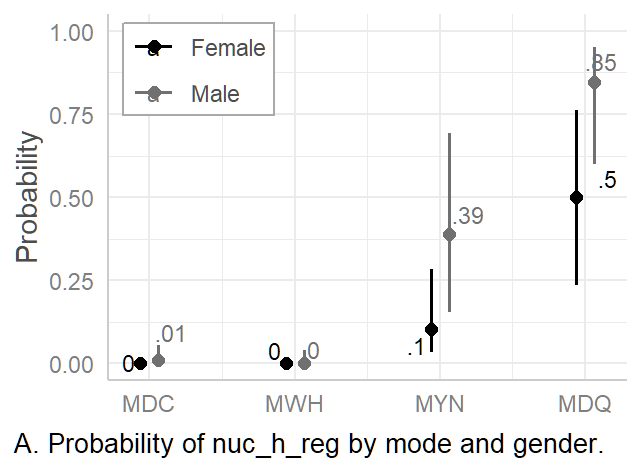

```r
ggpredict(h_reg_model,
  terms = c("mode", "gender"),
  ci.lvl = 0.95
) %>%
  plot() +
  labs(caption = "A. Probability of nuc_h_reg by mode and gender.") +
  geom_text_repel(
    aes(label = round(predicted, 2) %>% niceRatio()),
    size = 3,
    label.padding = units(3, "mm"),
    point.padding = units(2, "mm"),
  ) +
  scale_color_manual(
    labels = c("Female", "Male"),
    values = c("#000000", "#707070")
  ) +
  scale_y_continuous(limits = c(0, 1)) +
  ylab("Probability") +
  theme(
    panel.spacing.x = unit(1, "mm"),
    plot.title = element_blank(),
    axis.title.x = element_blank(),
    plot.caption = element_text(vjust = 1, hjust = 0, size = 10),
    plot.caption.position = "plot",
    legend.position = c(0.175, 0.975),
    legend.justification = "top",
    legend.margin = margin(0, 1, 0, 1, unit = "mm"),
    legend.spacing.y = unit(0, "mm"),
    legend.title = element_blank(),
    legend.background = element_rect(colour = "darkGray")
  )
```

```r
ggsave(
  filename =
    paste0(write, "_multi_pred.png"),
  ## width = 8.14,
  width = 8.5,
  height = 6.26,
  units = "cm",
  dpi = 300
)
```

##### prediction by factor

```r
printTidyPredictions(h_reg_model,
  caption_suffix = " (reg tier)",
  digits = 2
)
```

Predicted probabilities of nuc_H_reg (reg tier)

| mode | predicted | conf.low | conf.high | std.error |
| --- | --- | --- | --- | --- |
| MDC | < 0.01 | < 0.01 | 0.01 | 0.95 |
| MWH | < 0.01 | < 0.01 | < 0.01 | 1.67 |
| MYN | 0.1 | 0.03 | 0.28 | 0.62 |
| MDQ | 0.5 | 0.24 | 0.76 | 0.59 |

Predicted probabilities of nuc_H_reg (reg tier)

| gender | predicted | conf.low | conf.high | std.error |
| --- | --- | --- | --- | --- |
| F | < 0.01 | < 0.01 | 0.01 | 0.95 |
| M | < 0.01 | < 0.01 | 0.06 | 0.95 |

##### prediction by mode and gender

```r
x <- printTidyPredictions(h_reg_model,
  caption_suffix = " (reg tier)",
  digits = 2,
  factor_matrix = T
)
```

predicted probability of nuc_H_reg

| group | estimate | predicted | conf.low | conf.high | std.error |
| --- | --- | --- | --- | --- | --- |
| F | MDC | < 0.01 | < 0.01 | 0.01 | 0.95 |
| F | MWH | < 0.01 | < 0.01 | < 0.01 | 1.67 |
| F | MYN | 0.1 | 0.03 | 0.28 | 0.62 |
| F | MDQ | 0.5 | 0.24 | 0.76 | 0.59 |
| M | MDC | < 0.01 | < 0.01 | 0.06 | 0.95 |
| M | MWH | < 0.01 | < 0.01 | 0.04 | 1.66 |
| M | MYN | 0.39 | 0.15 | 0.69 | 0.64 |
| M | MDQ | 0.85 | 0.6 | 0.95 | 0.66 |

##### Pairwise comparisons

```r
charts <- getModelFixedFX(
  h_reg_model,
  write = write,
  exponentiate = T
)
```

nuc_H_reg ~ mode + gender + (1 | speaker) + (1 | prompt)

```r
# charts$intercepts %>% tidyStatNumbers()
charts$slopes %>% tidyStatNumbers()
```

b1: nuc_H_reg ~ mode + gender + (1 | speaker) + (1 | prompt)

| intercept | slope | estimate | conf.low | conf.high | std.error | z.value | p.value |
| --- | --- | --- | --- | --- | --- | --- | --- |
| modeMDC | modeMWH | 0.18 | 0.01 | 4.1 | 0.29 | -1.07 | .283 |
| modeMDC | modeMYN | 69.60 | 15.70 | 309.1 | 52.94 | 5.58 | < .001 |
| modeMDC | modeMDQ | 594.40 | 127.20 | 2777.2 | 467.55 | 8.12 | < .001 |
| modeMWH | modeMYN | 68.90 | 15.50 | 306.4 | 52.47 | 5.56 | < .001 |
| modeMWH | modeMDQ | 588.60 | 125.80 | 2753.6 | 463.37 | 8.1 | < .001 |
| modeMYN | modeMDQ | 9.14 | 4.84 | 17.2 | 2.96 | 6.83 | < .001 |
| intercept | genderM | 5.43 | 1.24 | 23.8 | 4.09 | 2.25 | .025 |

##### Model printout

```r
summary(h_reg_model)
```

```
## Cov prior  : speaker ~ wishart(df = 3.5, scale = Inf, posterior.scale = cov, common.scale = TRUE)
##            : prompt ~ wishart(df = 3.5, scale = Inf, posterior.scale = cov, common.scale = TRUE)
## Fixef prior: normal(sd = c(10, 2.5, ...), corr = c(0 ...), common.scale = FALSE)
## Prior dev  : 33.7782
##
## Generalized linear mixed model fit by maximum likelihood (Laplace
##   Approximation) [bglmerMod]
##  Family: binomial  ( logit )
## Formula: nuc_H_reg ~ mode + gender + (1 | speaker) + (1 | prompt)
##    Data: m_corpus_h_reg
##
##      AIC      BIC   logLik deviance df.resid
##    338.2    369.4   -162.1    324.2      632
##
## Scaled residuals:
##     Min      1Q  Median      3Q     Max
## -3.8269 -0.1790 -0.0447 -0.0150  3.0599
##
## Random effects:
##  Groups  Name        Variance Std.Dev.
##  speaker (Intercept) 1.5153   1.2310
##  prompt  (Intercept) 0.1848   0.4299
## Number of obs: 639, groups:  speaker, 11; prompt, 3
##
## Fixed effects:
##             Estimate Std. Error z value Pr(>|z|)
## (Intercept)  -6.3898     0.9529  -6.706 2.00e-11 ***
## modeMWH      -1.7054     1.5900  -1.073   0.2835
## modeMYN       4.2430     0.7605   5.580 2.41e-08 ***
## modeMDQ       6.3876     0.7865   8.121 4.61e-16 ***
## genderM       1.6990     0.7697   2.207   0.0273 *
## ---
## Signif. codes:  0 '***' 0.001 '**' 0.01 '*' 0.05 '.' 0.1 ' ' 1
##
## Correlation of Fixed Effects:
##         (Intr) modMWH modMYN modMDQ
## modeMWH -0.216
## modeMYN -0.759  0.273
## modeMDQ -0.783  0.261  0.915
## genderM -0.406 -0.004  0.024  0.070
```

#### Final Boundary and Mode

- Random intercepts only since models with random slopes generate singularity issues.

```r
m_corpus_boundaries <- m_corpus %>%
  mutate(`L%` = factor(str_replace_all(fin_phon, "\\[|\\]|\\^", ""),
    levels = c("%", "L%")
  ))

fin_phon_model <- bglmer(
  `L%` ~ mode + gender + (1 | speaker) + (1 | prompt),
  data = m_corpus_boundaries,
  family = binomial(link = "logit"),
  control = glmerControl(
    optimizer = "optimx",
    calc.derivs = F,
    optCtrl = list(
      method = "nlminb",
      starttests = F,
      kkt = F
    )
  )
)

fin_phon_model <- optimizeModel(fin_phon_model, reject_nm = F)
```

##### LRT

```r
write <- "output/Mode_fin_phon_GLMM"

model_formula <- getModelFormula(fin_phon_model)

write(
  paste(str_replace_all(model_formula, "\\`", ""), sep = ""),
  paste(write, "_formula.txt", sep = "")
)


## get, save, and print ANOVA of model
drop1_analysis <- drop1(fin_phon_model, test = "Chisq")

tibble(factor = row.names(drop1_analysis)) %>%
  cbind(tibble(drop1_analysis)) %>%
  filter(!is.na(npar)) %>%
  mutate(`p.adj (BH)` = NA, signif. = NA) %>%
  write_csv(paste0(write, "_anova.csv"))


adjustP_posthoc("output/",
  `Pr(Chi)`,
  suffix_id = "_anova"
)

read_csv(paste(write, "_anova.csv", sep = "")) %>%
  tidyStatNumbers() %>%
  formattable(caption = paste("Drop 1 ChiSq test of model:", model_formula))
```

Drop 1 ChiSq test of model: `L%` ~ mode + gender + (1 | speaker) + (1 | prompt)

| factor | npar | AIC | LRT | Pr(Chi) | p.adj (BH) | signif. |
| --- | --- | --- | --- | --- | --- | --- |
| mode | 3 | 481.66 | 62.77 | < .001 | < .001 | *p* < .05 |
| gender | 1 | 422.93 | 0.04 | .838 | .914 |  |

##### *R*<sup>2</sup> and prediction plots

Conditional and marginal R<sup>2</sup>

| marginal R<sup>2</sup> | conditional R<sup>2</sup> |
| --- | --- |
| .07 | .79 |

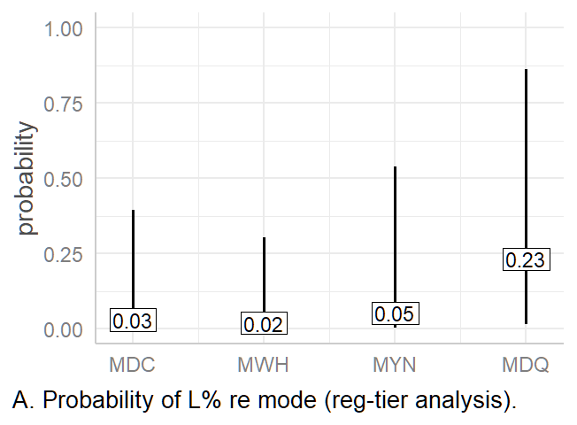

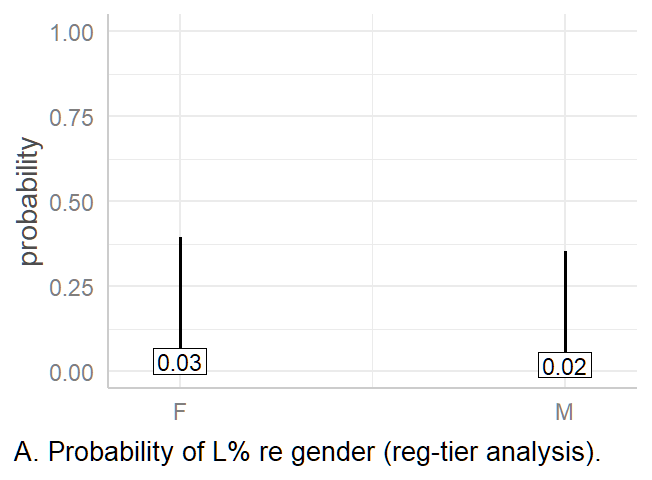

```r
tidy_summary <- analyseModel(
  fin_phon_model,
  write = write,
  is_GLM = T,
  type = "pred",
  caption_suffix = " (reg-tier analysis)",
  plot_rounding = 2,
  short_caption = T,
  caption_prefix = "A. Probability of"
)
```

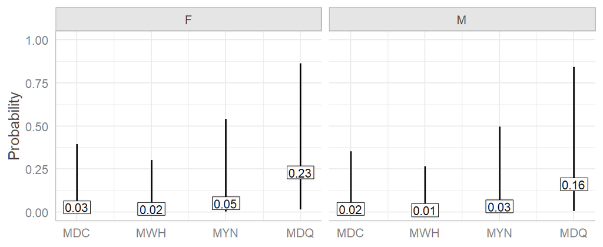

```r
ggpredict(fin_phon_model,
  terms = c("mode", "gender"),
  ci.lvl = 0.95
) %>%
  plot(grid = T, colors = "bw") +
  geom_label(
    aes(label = round(predicted, 2)),
    label.padding = unit(0.5, "mm"),
    label.r = unit(0.0, "mm"),
    size = 3
  ) +
  scale_y_continuous(limits = c(0, 1)) +
  ylab("Probability") +
  theme(
    plot.title = element_blank(),
    axis.title.x = element_blank(),
    plot.caption = element_text(hjust = 0, size = 10),
    plot.caption.position = "plot",
    legend.position = c(0.12, 0.8),
    legend.background = element_rect(colour = "darkGray")
  )
```

```r
ggsave(
  filename =
    paste0(write, "_multi_pred.png"),
  ## width = 8.14,
  width = 14,
  height = 6.26,
  units = "cm",
  dpi = 300
)
```

##### prediction by factor

```r
printTidyPredictions(fin_phon_model,
  caption_suffix = " (reg tier)",
  digits = 2
)
```

Predicted probabilities of L% (reg tier)

| mode | predicted | conf.low | conf.high | std.error |
| --- | --- | --- | --- | --- |
| MDC | 0.03 | < 0.01 | 0.39 | 1.57 |
| MWH | 0.02 | < 0.01 | 0.3 | 1.58 |
| MYN | 0.05 | < 0.01 | 0.54 | 1.56 |
| MDQ | 0.23 | 0.01 | 0.86 | 1.55 |

Predicted probabilities of L% (reg tier)

| gender | predicted | conf.low | conf.high | std.error |
| --- | --- | --- | --- | --- |
| F | 0.03 | < 0.01 | 0.39 | 1.57 |
| M | 0.02 | < 0.01 | 0.35 | 1.71 |

##### prediction by mode and gender

```r
x <- printTidyPredictions(fin_phon_model,
  caption_suffix = " (reg tier)",
  digits = 2,
  factor_matrix = T
)
```

predicted probability of L%

| group | estimate | predicted | conf.low | conf.high | std.error |
| --- | --- | --- | --- | --- | --- |
| F | MDC | 0.03 | < 0.01 | 0.39 | 1.57 |
| F | MWH | 0.02 | < 0.01 | 0.3 | 1.58 |
| F | MYN | 0.05 | < 0.01 | 0.54 | 1.56 |
| F | MDQ | 0.23 | 0.01 | 0.86 | 1.55 |
| M | MDC | 0.02 | < 0.01 | 0.35 | 1.71 |
| M | MWH | 0.01 | < 0.01 | 0.27 | 1.71 |
| M | MYN | 0.03 | < 0.01 | 0.5 | 1.7 |
| M | MDQ | 0.16 | < 0.01 | 0.84 | 1.69 |

##### pairwise comparisons

```r
charts <- getModelFixedFX(
  fin_phon_model,
  write = write,
  exponentiate = T
)
```

`L%` ~ mode + gender + (1 | speaker) + (1 | prompt)

```r
# charts$intercepts
charts$slopes %>% tidyStatNumbers()
```

b1: L% ~ mode + gender + (1 | speaker) + (1 | prompt)

| intercept | slope | estimate | conf.low | conf.high | std.error | z.value | p.value |
| --- | --- | --- | --- | --- | --- | --- | --- |
| modeMDC | modeMWH | 0.66 | 0.30 | 1.46 | 0.27 | -1.03 | .304 |
| modeMDC | modeMYN | 1.83 | 0.88 | 3.80 | 0.68 | 1.62 | .104 |
| modeMDC | modeMDQ | 10.10 | 4.71 | 21.60 | 3.92 | 5.95 | < .001 |
| modeMWH | modeMYN | 2.77 | 1.28 | 5.98 | 1.09 | 2.6 | .009 |
| modeMWH | modeMDQ | 15.30 | 6.80 | 34.30 | 6.3 | 6.6 | < .001 |
| modeMYN | modeMDQ | 5.51 | 2.69 | 11.30 | 2.01 | 4.68 | < .001 |
| intercept | genderM | 0.64 | 0.01 | 29.10 | 1.25 | -0.23 | .821 |

##### Model printout

```r
summary(fin_phon_model)
```

```
## Cov prior  : speaker ~ wishart(df = 3.5, scale = Inf, posterior.scale = cov, common.scale = TRUE)
##            : prompt ~ wishart(df = 3.5, scale = Inf, posterior.scale = cov, common.scale = TRUE)
## Prior dev  : -4.5085
##
## Generalized linear mixed model fit by maximum likelihood (Laplace
##   Approximation) [bglmerMod]
##  Family: binomial  ( logit )
## Formula: `L%` ~ mode + gender + (1 | speaker) + (1 | prompt)
##    Data: m_corpus_boundaries
## Control:
## glmerControl(optimizer = "optimx", calc.derivs = F, optCtrl = list(method = "nlminb",
##     starttests = F, kkt = F))
##
##      AIC      BIC   logLik deviance df.resid
##    424.9    456.1   -205.4    410.9      632
##
## Scaled residuals:
##     Min      1Q  Median      3Q     Max
## -3.7394 -0.3245 -0.1098 -0.0274  4.1437
##
## Random effects:
##  Groups  Name        Variance Std.Dev.
##  speaker (Intercept) 9.403    3.066
##  prompt  (Intercept) 2.148    1.466
## Number of obs: 639, groups:  speaker, 11; prompt, 3
##
## Fixed effects:
##             Estimate Std. Error z value Pr(>|z|)
## (Intercept)  -3.5112     1.5701  -2.236   0.0253 *
## modeMWH      -0.4147     0.4035  -1.028   0.3041
## modeMYN       0.6048     0.3725   1.623   0.1045
## modeMDQ       2.3111     0.3887   5.946 2.75e-09 ***
## genderM      -0.4412     1.9455  -0.227   0.8206
## ---
## Signif. codes:  0 '***' 0.001 '**' 0.01 '*' 0.05 '.' 0.1 ' ' 1
##
## Correlation of Fixed Effects:
##         (Intr) modMWH modMYN modMDQ
## modeMWH -0.113
## modeMYN -0.135  0.491
## modeMDQ -0.172  0.458  0.541
## genderM -0.547  0.000  0.000  0.013
```

## 7.5.3 Comparing Both Analyses

### BGLMM Analysis

#### likelihood of H% in non-register tier analysis

Conditional and marginal R<sup>2</sup>

| marginal R<sup>2</sup> | conditional R<sup>2</sup> |
| --- | --- |
| .33 | .74 |

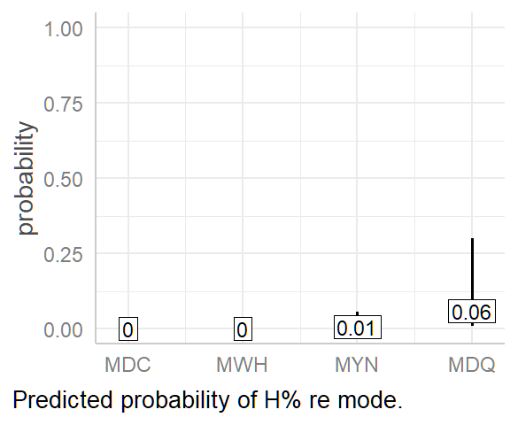

```r
write <- "output/comp_fin_phon_H_GLMM"

fin_phon_model_H_or_not <- bglmer(
  `H%` ~ mode + (1 | speaker) + (1 | prompt),
  data = m_corpus_comp,
  family = binomial(link = "logit"),
  fixef.prior = normal()
)

fin_phon_model_H_null <- bglmer(
  `H%` ~ 1 + (1 | speaker) + (1 | prompt),
  data = m_corpus_comp,
  family = binomial(link = "logit")
)


tidy_summary_non_reg <- analyseModel(fin_phon_model_H_or_not,
  is_GLM = T,
  type = "pred",
  short_caption = F,
  plot_rounding = 2
)
```

```r
tidy_summary_non_reg$table %>% tidyStatNumbers()
```

summary of: H% ~ mode + (1 | speaker) + (1 | prompt)

| term | estimate | conf.low | conf.high | std.error | z.value | p.value |
| --- | --- | --- | --- | --- | --- | --- |
| (Intercept) | 0.00 | 0.00 | 0.01 | 0 | -5.17 | < .001 |
| modeMWH | 0.26 | 0.01 | 7.43 | 0.44 | -0.79 | .43 |
| modeMYN | 6.82 | 0.96 | 48.30 | 6.81 | 1.92 | .054 |
| modeMDQ | 63.20 | 9.84 | 405.80 | 59.96 | 4.37 | < .001 |

```r
true_anova <- anova(fin_phon_model_H_null, fin_phon_model_H_or_not)

## create fake ANOVA to get p.adj(BH) values
true_anova %>%
  tidy() %>%
  filter(!is.na(df)) %>%
  relocate(df, .after = term) %>%
  select(-c(npar, BIC, logLik, deviance)) %>%
  mutate(`p.adj (BH)` = NA, signif. = NA) %>%
  rename(factor = term) %>%
  rename(LRT = statistic) %>%
  rename(npar = df) %>%
  rename(`Pr(Chi)` = p.value) %>%
  write_csv(paste0(write, "_anova.csv"))


adjustP_posthoc("output/",
  `Pr(Chi)`,
  suffix_id = "_anova"
)


true_anova %>%
  tidy() %>%
  filter(!is.na(df)) %>%
  cbind(read_csv(paste(write, "_anova.csv", sep = "")) %>%
    select(`p.adj (BH)`, signif.)) %>%
  tidyStatNumbers() %>%
  formattable(caption = paste(
    "ANOVA of model:",
    getModelFormula(fin_phon_model_H_or_not)
  )) %>%
  rename(`chi^2^` = statistic)
```

ANOVA of model: `H%` ~ mode + (1 | speaker) + (1 | prompt)

| term | npar | AIC | BIC | logLik | deviance | chi<sup>2</sup> | df | p.value | p.adj (BH) | signif. |
| --- | --- | --- | --- | --- | --- | --- | --- | --- | --- | --- |
| fin_phon_model_H_or_not | 6 | 165.64 | 192.4 | -76.82 | 153.64 | 65.3 | 3 | < .001 | < .001 | *p* < .05 |

#### Likelihood of high register in register-tier analysis

Conditional and marginal R<sup>2</sup>

| marginal R<sup>2</sup> | conditional R<sup>2</sup> |
| --- | --- |
| .63 | .8 |

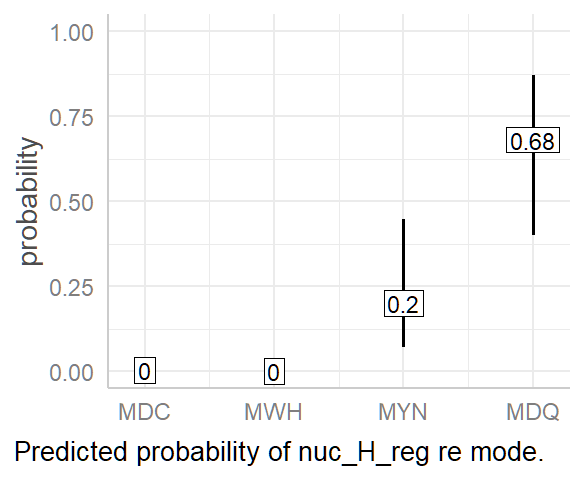

```r
write <- "output/comp_H_reg_GLMM"

h_reg_model <- bglmer(
  nuc_H_reg ~ mode + (1 | speaker) + (1 | prompt),
  data = m_corpus_comp,
  family = binomial(link = "logit"),
  fixef.prior = normal()
)

h_reg_model_null <- bglmer(
  nuc_H_reg ~ 1 + (1 | speaker) + (1 | prompt),
  data = m_corpus_comp,
  family = binomial(link = "logit")
)

tidy_summary_reg <- analyseModel(h_reg_model,
  is_GLM = T,
  type = "pred",
  short_caption = F,
  plot_rounding = 2
)
```

```r
tidy_summary_reg$table %>% tidyStatNumbers()
```

summary of: nuc_H_reg ~ mode + (1 | speaker) + (1 | prompt)

| term | estimate | conf.low | conf.high | std.error | z.value | p.value |
| --- | --- | --- | --- | --- | --- | --- |
| (Intercept) | 0.00 | 0.00 | 0.02 | 0 | -6.04 | < .001 |
| modeMWH | 0.18 | 0.01 | 4.12 | 0.29 | -1.07 | .285 |
| modeMYN | 69.60 | 15.60 | 309.90 | 53.03 | 5.57 | < .001 |
| modeMDQ | 591.20 | 126.10 | 2771.80 | 466.06 | 8.1 | < .001 |

```r
true_anova <- anova(h_reg_model_null, h_reg_model)

## create fake ANOVA to get p.adj(BH) values
true_anova %>%
  tidy() %>%
  filter(!is.na(df)) %>%
  relocate(df, .after = term) %>%
  select(-c(npar, BIC, logLik, deviance)) %>%
  mutate(`p.adj (BH)` = NA, signif. = NA) %>%
  rename(factor = term) %>%
  rename(LRT = statistic) %>%
  rename(npar = df) %>%
  rename(`Pr(Chi)` = p.value) %>%
  write_csv(paste0(write, "_anova.csv"))


adjustP_posthoc("output/",
  `Pr(Chi)`,
  suffix_id = "_anova"
)

true_anova %>%
  tidy() %>%
  filter(!is.na(df)) %>%
  cbind(read_csv(paste(write, "_anova.csv", sep = "")) %>%
    select(`p.adj (BH)`, signif.)) %>%
  tidyStatNumbers() %>%
  formattable(caption = paste(
    "ANOVA of model:",
    getModelFormula(h_reg_model)
  )) %>%
  rename(`chi^2^` = statistic)
```

ANOVA of model: nuc_H_reg ~ mode + (1 | speaker) + (1 | prompt)

| term | npar | AIC | BIC | logLik | deviance | chi<sup>2</sup> | df | p.value | p.adj (BH) | signif. |
| --- | --- | --- | --- | --- | --- | --- | --- | --- | --- | --- |
| h_reg_model | 6 | 341.59 | 368.35 | -164.79 | 329.59 | 318.59 | 3 | < .001 | < .001 | *p* < .05 |

## 7.5.4-5 Utterance-wide Phonology

### Raw Data

```r
# set lower limit for list: more than 8 tokens in the corpus
tot_rows <- nrow(m_corpus)
threshold <- round(tot_rows / 4 / 20, 0)

keep_list <- m_corpus %>%
  mutate(phr_phon = factor(phr_phon, levels = unique(phr_phon))) %>%
  group_by(phr_phon) %>%
  summarise(phon_count = n()) %>%
  filter(phon_count >= threshold)
```

#### Utterance-wide Intonation

##### Mode

```r
## List utterances phonology by mode with 8+ tokens in the corpus
m_corpus %>%
  mutate(phr_phon = factor(phr_phon, levels = unique(phr_phon))) %>%
  filter(phr_phon %in% keep_list$phr_phon) %>%
  group_by(mode, phr_phon) %>%
  summarise(phon_count = n(), .groups = "rowwise") %>%
  arrange(desc(phon_count)) %>%
  mutate(phr_phon = str_replace_all(
    phr_phon,
    "([\\*\\[\\^\\>])", "\\\\\\1"
  )) %>%
  pivot_wider(
    names_from = mode,
    values_from = phon_count,
    values_fill = 0
  ) %>%
  select(phr_phon, MDC, MWH, MYN, MDQ) %>%
  rowwise(phr_phon) %>%
  mutate(total = sum(c_across())) %>%
  tibble::rowid_to_column("#") %>%
  rename("Phonology" = phr_phon) %>%
  formattable(
    align = "r",
    caption = paste(
      "Utterance level intonational phonology by mode ",
      "for tokens accounting for at least ",
      percent(threshold / tot_rows),
      " of all tokens.",
      sep = ""
    ),
    list(
      area(col = 3:6) ~ proportion_bar(color = c(
        rep(brewer.pal(4, "Pastel2")[3], nrow(.)),
        rep(brewer.pal(4, "Pastel2")[2], nrow(.)),
        rep(brewer.pal(4, "Pastel2")[1], nrow(.)),
        rep(brewer.pal(4, "Pastel2")[4], nrow(.))
      )),
      total = proportion_bar(color = "#aaaaaa")
    )
  )
```

Utterance level intonational phonology by mode for tokens accounting for at least 1.25% of all tokens.

| # | Phonology | MDC | MWH | MYN | MDQ | total |
| --- | --- | --- | --- | --- | --- | --- |
| 1 | % H* L* L*H % | 4 | 50 | 0 | 0 | 54 |
| 2 | % H* L*H % | 33 | 0 | 4 | 0 | 37 |
| 3 | % L*H % | 32 | 0 | 31 | 15 | 78 |
| 4 | % >H* L*H % | 30 | 0 | 24 | 7 | 61 |
| 5 | % L*H L*H % | 25 | 0 | 26 | 13 | 64 |
| 6 | % H* L*!H L*H % | 0 | 21 | 0 | 0 | 21 |
| 7 | % >H* ^[L*H] % | 0 | 0 | 14 | 19 | 33 |
| 8 | % H* L*H L*H % | 0 | 17 | 0 | 0 | 17 |
| 9 | % H* !H* L*H % | 5 | 16 | 0 | 0 | 21 |
| 10 | % L*H L% | 1 | 0 | 12 | 0 | 13 |
| 11 | % >H* L*H L% | 10 | 0 | 2 | 1 | 13 |
| 12 | % L*H ^[L*H] % | 0 | 0 | 3 | 10 | 13 |
| 13 | % L*^[H] % | 0 | 0 | 4 | 9 | 13 |
| 14 | % >H* L*!H L*H % | 0 | 8 | 0 | 0 | 8 |
| 15 | % H* L*H % | 3 | 8 | 1 | 0 | 12 |
| 16 | % H* ^[L*H] % | 0 | 0 | 7 | 5 | 12 |
| 17 | % H* L*H L% | 6 | 0 | 2 | 0 | 8 |
| 18 | % ^[L*H] % | 0 | 0 | 6 | 6 | 12 |

```r
## get tibble of total counts per cell
total_counts <- m_corpus %>%
  group_by(mode) %>%
  summarise(phon_count = n(), .groups = "rowwise") %>%
  arrange(desc(phon_count)) %>%
  pivot_wider(
    names_from = mode,
    values_from = phon_count,
    values_fill = 0
  ) %>%
  mutate(total = sum(c_across())) %>%
  select(MDC, MWH, MYN, MDQ, total)
```

##### All

```r
## List all utterance phonology
m_corpus %>%
  mutate(phr_phon = factor(phr_phon, levels = unique(phr_phon))) %>%
  group_by(phr_phon) %>%
  summarise(phon_count = n()) %>%
  arrange(desc(phon_count)) %>%
  mutate(
    phr_phon = str_replace_all(phr_phon, "([\\*\\[\\^\\>])", "\\\\\\1")
  ) %>%
  formattable(
    caption = "Utterance level intonational phonology in M-corpus "
  )
```

Utterance level intonational phonology in M-corpus

| phr_phon | phon_count |
| --- | --- |
| % L*H % | 78 |
| % L*H L*H % | 64 |
| % >H* L*H % | 61 |
| % H* L* L*H % | 54 |
| % H* L*H % | 37 |
| % >H* ^[L*H] % | 33 |
| % H* L*!H L*H % | 21 |
| % H* !H* L*H % | 21 |
| % H* L*H L*H % | 17 |
| % >H* L*H L% | 13 |
| % L*^[H] % | 13 |
| % L*H L% | 13 |
| % L*H ^[L*H] % | 13 |
| % ^[L*H] % | 12 |
| % H* L*H % | 12 |
| % H* ^[L*H] % | 12 |
| % H* L*H L% | 8 |
| % >H* L*!H L*H % | 8 |
| % L*H L*H L% | 7 |
| % >H* ^[L*H] L% | 7 |
| % L*^[H L%] | 6 |
| ^[% L*H %] | 6 |
| % L*H L*!H L*H L% | 6 |
| % >H* L* L*H % | 5 |
| % H* L* L*H L% | 5 |
| %H L*H L*H % | 5 |
| %H L*H % | 5 |
| % >H* ^[L*H L%] | 5 |
| % ^[H*] L* L*H % | 5 |
| % H* ^[L*H L%] | 5 |

[output cut: 54 more lines]

#### Possible Q-Signalling Events

##### Nuclear PA-only

```r
nuc_only <- m_corpus %>%
  filter(nuc_PA_only == T) %>%
  group_by(mode) %>%
  summarise(phon_count = n(), .groups = "rowwise") %>%
  arrange(desc(phon_count)) %>%
  pivot_wider(
    names_from = mode,
    values_from = phon_count,
    values_fill = 0
  ) %>%
  mutate(total = sum(c_across())) %>%
  select(MDC, MWH, MYN, MDQ, total)

nuc_only %>%
  rbind(round((nuc_only / total_counts * 100), 1) %>% paste("%", sep = "")) %>%
  mutate("info" = c("count", "percentage"), .before = 1) %>%
  kable(
    caption = "Utterance level intonational phonology by mode for tokens with only one PA"
  ) %>%
  kable_styling(full_width = F, position = "left")
```

Utterance level intonational phonology by mode for tokens with only one PA

| info | MDC | MWH | MYN | MDQ | total |
| --- | --- | --- | --- | --- | --- |
| count | 36 | 1 | 56 | 54 | 147 |
| percentage | 22.1% | 0.6% | 34.6% | 35.3% | 23% |

##### High register in nuclear PA

```r
uses_h_reg <- m_corpus %>%
  filter(`high register in nucleus` == T) %>%
  group_by(mode) %>%
  summarise(phon_count = n(), .groups = "rowwise") %>%
  complete(mode, fill = list(phon_count = 0)) %>%
  arrange(desc(phon_count)) %>%
  pivot_wider(
    names_from = mode,
    values_from = phon_count,
    values_fill = 0
  ) %>%
  mutate(total = sum(c_across())) %>%
  select(MDC, MWH, MYN, MDQ, total)

uses_h_reg %>%
  rbind(round((uses_h_reg / total_counts * 100), 1) %>% paste("%", sep = "")) %>%
  mutate("info" = c("count", "percentage"), .before = 1) %>%
  kable(
    caption = "High register in nuclear PA"
  ) %>%
  kable_styling(full_width = F, position = "left")
```

High register in nuclear PA

| info | MDC | MWH | MYN | MDQ | total |
| --- | --- | --- | --- | --- | --- |
| count | 0 | 0 | 45 | 96 | 141 |
| percentage | 0% | 0% | 27.8% | 62.7% | 22.1% |

##### Either

```r
uses_h_reg_or_nuc_PA_only <- m_corpus %>%
  filter(`high register in nucleus` == T | nuc_PA_only == T) %>%
  group_by(mode) %>%
  summarise(phon_count = n(), .groups = "rowwise") %>%
  arrange(desc(phon_count)) %>%
  pivot_wider(
    names_from = mode,
    values_from = phon_count,
    values_fill = 0
  ) %>%
  mutate(total = sum(c_across())) %>%
  select(MDC, MWH, MYN, MDQ, total)

uses_h_reg_or_nuc_PA_only %>%
  rbind(round((uses_h_reg_or_nuc_PA_only / total_counts * 100), 1) %>% paste("%", sep = "")) %>%
  mutate("info" = c("count", "percentage"), .before = 1) %>%
  kable(
    caption = paste(
      "Utterance level intonational phonology by mode with",
      "high register or nuclear PA only"
    )
  ) %>%
  kable_styling(full_width = F, position = "left")
```

Utterance level intonational phonology by mode with high register or nuclear PA only

| info | MDC | MWH | MYN | MDQ | total |
| --- | --- | --- | --- | --- | --- |
| count | 36 | 1 | 91 | 122 | 250 |
| percentage | 22.1% | 0.6% | 56.2% | 79.7% | 39.1% |

### BGLMM analysis

#### Nuclear PA only

```r
nuc_pa_only_model <- bglmer(
  nuc_PA_only ~ mode + gender + (1 | speaker) + (1 | prompt),
  data = m_corpus,
  fixef.prior = normal(),
  family = binomial(link = "logit"),
  ## change optimizer to avoid convergence errors
  control = glmerControl(
    optimizer = "optimx",
    calc.derivs = F,
    optCtrl = list(
      method = "nlminb",
      starttests = F,
      kkt = F
    )
  )
)
h_reg_model <- optimizeModel(nuc_pa_only_model, reject_nm = F)
```

##### LRT

```r
write <- "output/Utt_nuc_pa_only_GLMM"

model_formula <- getModelFormula(nuc_pa_only_model)

write(
  paste(str_replace_all(model_formula, "\\`", ""), sep = ""),
  paste(write, "_formula.txt", sep = "")
)


## get, save, and print ANOVA of model
drop1_analysis <- drop1(nuc_pa_only_model, test = "Chisq")

tibble(factor = row.names(drop1_analysis)) %>%
  cbind(tibble(drop1_analysis)) %>%
  filter(!is.na(npar)) %>%
  mutate(`p.adj (BH)` = NA, signif. = NA) %>%
  write_csv(paste0(write, "_anova.csv"))


adjustP_posthoc("output/",
  `Pr(Chi)`,
  suffix_id = "_anova"
)

read_csv(paste(write, "_anova.csv", sep = "")) %>%
  tidyStatNumbers() %>%
  formattable(caption = paste("Drop 1 ChiSq test of model:", model_formula))
```

Drop 1 ChiSq test of model: nuc_PA_only ~ mode + gender + (1 | speaker) + (1 | prompt)

| factor | npar | AIC | LRT | Pr(Chi) | p.adj (BH) | signif. |
| --- | --- | --- | --- | --- | --- | --- |
| mode | 3 | 576.7 | 114.1 | < .001 | < .001 | *p* < .05 |
| gender | 1 | 472.06 | 5.47 | .019 | .027 | *p* < .05 |

##### *R*<sup>2</sup> and prediction plots

Conditional and marginal R<sup>2</sup>

| marginal R<sup>2</sup> | conditional R<sup>2</sup> |
| --- | --- |
| .39 | .75 |

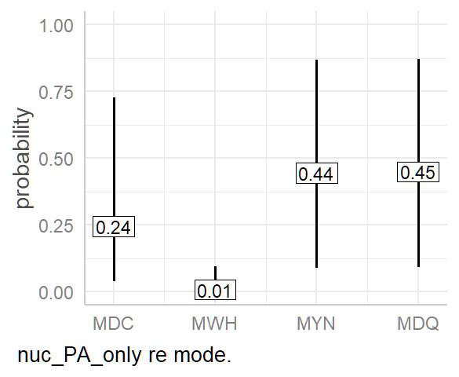

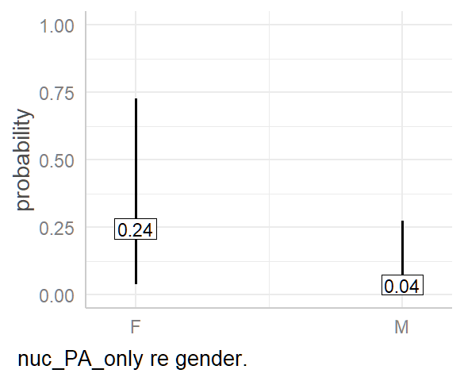

```r
tidy_summary <- analyseModel(nuc_pa_only_model,
  write = write,
  is_GLM = T,
  type = "pred",
  plot_rounding = 2,
  short_caption = T
)
```

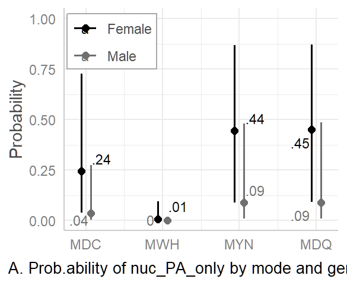

```r
my_plot <-
  ggpredict(nuc_pa_only_model,
    terms = c("mode", "gender"),
    ci.lvl = 0.95
  ) %>%
  plot() +
  labs(caption = "A. Prob.ability of nuc_PA_only by mode and gender.") +
  geom_text_repel(
    seed = 55,
    force = 4,
    aes(label = round(predicted, 2) %>% niceRatio()),
    size = 3,
  ) +
  scale_color_manual(
    labels = c("Female", "Male"),
    values = c("#000000", "#707070")
  ) +
  scale_y_continuous(limits = c(0, 1)) +
  ylab("Probability") +
  theme(
    panel.spacing.x = unit(1, "mm"),
    plot.title = element_blank(),
    axis.title.x = element_blank(),
    plot.caption = element_text(vjust = 1, hjust = 0, size = 10),
    plot.caption.position = "plot",
    legend.position = c(0.175, 0.975),
    legend.justification = "top",
    legend.margin = margin(0, 1, 0, 1, unit = "mm"),
    legend.spacing.y = unit(0, "mm"),
    legend.title = element_blank(),
    legend.background = element_rect(colour = "darkGray")
  )

ggsave(
  filename =
    paste0(write, "_multi_pred.png"),
  plot = my_plot,
  ## width = 8.14,
  width = 8.5,
  height = 6.26,
  units = "cm",
  dpi = 300
)

print(my_plot)
```

##### prediction tables

```r
printTidyPredictions(nuc_pa_only_model,
  caption_suffix = "(reg tier)",
  digits = 3
)
```

Predicted probabilities of nuc_PA_only (reg tier)

| mode | predicted | conf.low | conf.high | std.error |
| --- | --- | --- | --- | --- |
| MDC | 0.244 | 0.038 | 0.727 | 1.076 |
| MWH | 0.007 | < 0.001 | 0.094 | 1.346 |
| MYN | 0.445 | 0.089 | 0.867 | 1.072 |
| MDQ | 0.449 | 0.091 | 0.87 | 1.072 |

Predicted probabilities of nuc_PA_only (reg tier)

| gender | predicted | conf.low | conf.high | std.error |
| --- | --- | --- | --- | --- |
| F | 0.244 | 0.038 | 0.727 | 1.076 |
| M | 0.037 | 0.004 | 0.274 | 1.164 |

##### prediction by mode and gender

```r
x <- printTidyPredictions(nuc_pa_only_model,
  caption_suffix = " (reg tier)",
  digits = 3,
  factor_matrix = T
)
```

predicted probability of nuc_PA_only

| group | estimate | predicted | conf.low | conf.high | std.error |
| --- | --- | --- | --- | --- | --- |
| F | MDC | 0.244 | 0.038 | 0.727 | 1.076 |
| F | MWH | 0.007 | < 0.001 | 0.094 | 1.346 |
| F | MYN | 0.445 | 0.089 | 0.867 | 1.072 |
| F | MDQ | 0.449 | 0.091 | 0.87 | 1.072 |
| M | MDC | 0.037 | 0.004 | 0.274 | 1.164 |
| M | MWH | < 0.001 | < 0.001 | 0.014 | 1.424 |
| M | MYN | 0.087 | 0.01 | 0.479 | 1.155 |
| M | MDQ | 0.089 | 0.01 | 0.484 | 1.156 |

##### pairwise comparisons

```r
charts <- getModelFixedFX(
  nuc_pa_only_model,
  write = write,
  exponentiate = T
)
```

nuc_PA_only ~ mode + gender + (1 | speaker) + (1 | prompt)

```r
# charts$intercepts
charts$slopes %>% tidyStatNumbers()
```

b1: nuc_PA_only ~ mode + gender + (1 | speaker) + (1 | prompt)

| intercept | slope | estimate | conf.low | conf.high | std.error | z.value | p.value |
| --- | --- | --- | --- | --- | --- | --- | --- |
| modeMDC | modeMWH | 0.02 | 0.00 | 0.12 | 0.02 | -4.37 | < .001 |
| modeMDC | modeMYN | 2.48 | 1.37 | 4.50 | 0.75 | 2.99 | .003 |
| modeMDC | modeMDQ | 2.53 | 1.39 | 4.61 | 0.78 | 3.03 | .002 |
| modeMWH | modeMYN | 56.80 | 15.20 | 212.00 | 38.17 | 6.01 | < .001 |
| modeMWH | modeMDQ | 57.90 | 15.50 | 216.50 | 38.95 | 6.03 | < .001 |
| modeMYN | modeMDQ | 1.06 | 0.60 | 1.86 | 0.31 | 0.19 | .847 |
| intercept | genderM | 0.12 | 0.01 | 0.95 | 0.13 | -2.01 | .044 |

##### Model printout

```r
summary(nuc_pa_only_model)
```

```
## Cov prior  : speaker ~ wishart(df = 3.5, scale = Inf, posterior.scale = cov, common.scale = TRUE)
##            : prompt ~ wishart(df = 3.5, scale = Inf, posterior.scale = cov, common.scale = TRUE)
## Fixef prior: normal(sd = c(10, 2.5, ...), corr = c(0 ...), common.scale = FALSE)
## Prior dev  : 21.9236
##
## Generalized linear mixed model fit by maximum likelihood (Laplace
##   Approximation) [bglmerMod]
##  Family: binomial  ( logit )
## Formula: nuc_PA_only ~ mode + gender + (1 | speaker) + (1 | prompt)
##    Data: m_corpus
## Control:
## glmerControl(optimizer = "optimx", calc.derivs = F, optCtrl = list(method = "nlminb",
##     starttests = F, kkt = F))
##
##      AIC      BIC   logLik deviance df.resid
##    468.6    499.8   -227.3    454.6      632
##
## Scaled residuals:
##     Min      1Q  Median      3Q     Max
## -2.7675 -0.4036 -0.0991 -0.0094  8.3518
##
## Random effects:
##  Groups  Name        Variance Std.Dev.
##  speaker (Intercept) 2.665    1.632
##  prompt  (Intercept) 1.974    1.405
## Number of obs: 639, groups:  speaker, 11; prompt, 3
##
## Fixed effects:
##             Estimate Std. Error z value Pr(>|z|)
## (Intercept)  -1.1314     1.0763  -1.051  0.29316
## modeMWH      -3.7780     0.8654  -4.366 1.27e-05 ***
## modeMYN       0.9085     0.3042   2.986  0.00282 **
## modeMDQ       0.9282     0.3065   3.028  0.00246 **
## genderM      -2.1253     1.0567  -2.011  0.04430 *
## ---
## Signif. codes:  0 '***' 0.001 '**' 0.01 '*' 0.05 '.' 0.1 ' ' 1
##
## Correlation of Fixed Effects:
##         (Intr) modMWH modMYN modMDQ
## modeMWH -0.051
## modeMYN -0.154  0.174
## modeMDQ -0.155  0.173  0.551
## genderM -0.404  0.010 -0.022 -0.016
```

#### Either Nuc-PA or High Reg

##### model summary

```r
h_reg_or_nuc_pa_only_model <- bglmer(
  `at_least_1_strat` ~ mode + gender + (1 | speaker) + (1 | prompt),
  data = m_corpus,
  family = binomial(link = "logit"),
  ## change optimizer to avoid convergence errors
  control = glmerControl(
    optimizer = "optimx",
    calc.derivs = F,
    optCtrl = list(
      method = "nlminb",
      starttests = F,
      kkt = F
    )
  )
)

h_reg_model <- optimizeModel(h_reg_or_nuc_pa_only_model, reject_nm = F)
```

```
## Searching for good optimization settings with optimizeModel().
##   Formula:   at_least_1_strat ~ mode + gender + (1 | speaker) + (1 | prompt)
##   Optimizer: optimx
##
## Model found using optimx after trying original model.
```

```r
summary(h_reg_or_nuc_pa_only_model)
```

```
## Cov prior  : speaker ~ wishart(df = 3.5, scale = Inf, posterior.scale = cov, common.scale = TRUE)
##            : prompt ~ wishart(df = 3.5, scale = Inf, posterior.scale = cov, common.scale = TRUE)
## Prior dev  : -1.515
##
## Generalized linear mixed model fit by maximum likelihood (Laplace
##   Approximation) [bglmerMod]
##  Family: binomial  ( logit )
## Formula: at_least_1_strat ~ mode + gender + (1 | speaker) + (1 | prompt)
##    Data: m_corpus
## Control:
## glmerControl(optimizer = "optimx", calc.derivs = F, optCtrl = list(method = "nlminb",
##     starttests = F, kkt = F))
##
##      AIC      BIC   logLik deviance df.resid
##    487.7    519.0   -236.9    473.7      632
##
## Scaled residuals:
##     Min      1Q  Median      3Q     Max
## -6.0349 -0.3533 -0.0470  0.3933 15.8488
##
## Random effects:
##  Groups  Name        Variance Std.Dev.
##  speaker (Intercept) 1.655    1.287
##  prompt  (Intercept) 1.659    1.288
## Number of obs: 639, groups:  speaker, 11; prompt, 3
##
## Fixed effects:
##             Estimate Std. Error z value Pr(>|z|)
## (Intercept) -1.68626    0.94468  -1.785   0.0743 .
## modeMWH     -4.24418    1.08942  -3.896 9.79e-05 ***
## modeMYN      2.06629    0.29979   6.893 5.48e-12 ***
## modeMDQ      3.57313    0.35405  10.092  < 2e-16 ***
## genderM     -0.06275    0.81600  -0.077   0.9387
## ---
## Signif. codes:  0 '***' 0.001 '**' 0.01 '*' 0.05 '.' 0.1 ' ' 1
##
## Correlation of Fixed Effects:
##         (Intr) modMWH modMYN modMDQ
## modeMWH -0.035
## modeMYN -0.191  0.113
## modeMDQ -0.178  0.085  0.575
## genderM -0.391 -0.010  0.005  0.009
```

##### LRT

```r
write <- "output/Utt_h_reg_or_nuc_pa_only_GLMM"

model_formula <- getModelFormula(h_reg_or_nuc_pa_only_model)

write(
  paste(str_replace_all(model_formula, "\\`", ""), sep = ""),
  paste(write, "_formula.txt", sep = "")
)


## get, save, and print ANOVA of model
drop1_analysis <- drop1(h_reg_or_nuc_pa_only_model, test = "Chisq")

tibble(factor = row.names(drop1_analysis)) %>%
  cbind(tibble(drop1_analysis)) %>%
  filter(!is.na(npar)) %>%
  mutate(`p.adj (BH)` = NA, signif. = NA) %>%
  write_csv(paste0(write, "_anova.csv"))


adjustP_posthoc("output/",
  `Pr(Chi)`,
  suffix_id = "_anova"
)

read_csv(paste(write, "_anova.csv", sep = "")) %>%
  tidyStatNumbers() %>%
  formattable(caption = paste("Drop 1 ChiSq test of model:", model_formula))
```

Drop 1 ChiSq test of model: at_least_1_strat ~ mode + gender + (1 | speaker) + (1 | prompt)

| factor | npar | AIC | LRT | Pr(Chi) | p.adj (BH) | signif. |
| --- | --- | --- | --- | --- | --- | --- |
| mode | 3 | 821.22 | 339.47 | < .001 | < .001 | *p* < .05 |
| gender | 1 | 485.76 | 0.01 | .932 | .932 |  |

##### *R*<sup>2</sup> and prediction plots

Conditional and marginal R<sup>2</sup>

| marginal R<sup>2</sup> | conditional R<sup>2</sup> |
| --- | --- |
| .57 | .78 |

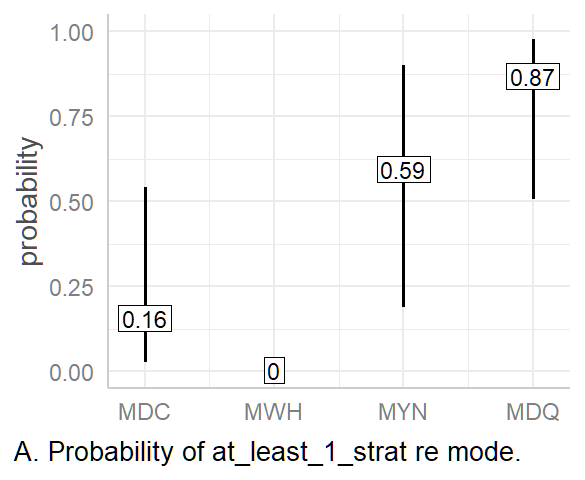

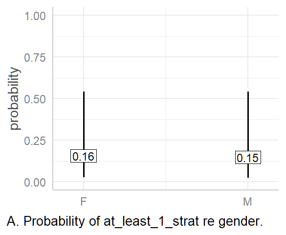

```r
tidy_summary <- analyseModel(h_reg_or_nuc_pa_only_model,
  write = write,
  is_GLM = T,
  type = "pred",
  plot_rounding = 2,
  short_caption = T,
  caption_prefix = "A. Probability of"
)
```

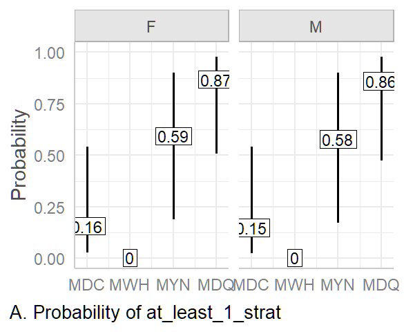

```r
my_plot <-
  ggpredict(h_reg_or_nuc_pa_only_model,
    terms = c("mode", "gender"),
    ci.lvl = 0.95
  ) %>%
  plot(grid = T, colors = "bw") +
  labs(caption = "A. Probability of at_least_1_strat") +
  geom_label(
    aes(label = round(predicted, 2)),
    label.padding = unit(0.5, "mm"),
    label.r = unit(0.0, "mm"),
    size = 3
  ) +
  scale_y_continuous(limits = c(0, 1)) +
  ylab("Probability") +
  theme(
    plot.title = element_blank(),
    axis.title.x = element_blank(),
    plot.caption = element_text(hjust = 0, size = 10),
    plot.caption.position = "plot",
    legend.position = c(0.12, 0.8),
    legend.background = element_rect(colour = "darkGray")
  )

ggsave(
  filename =
    paste0(write, "_multi_pred.png"),
  plot = my_plot,
  ## width = 8.14,
  width = 7.7,
  height = 6.26,
  units = "cm",
  dpi = 300
)

print(my_plot)
```

##### Prediction tables

```r
printTidyPredictions(h_reg_or_nuc_pa_only_model,
  caption_suffix = "(reg tier)",
  digits = 3
)
```

Predicted probabilities of at_least_1_strat (reg tier)

| mode | predicted | conf.low | conf.high | std.error |
| --- | --- | --- | --- | --- |
| MDC | 0.156 | 0.028 | 0.541 | 0.945 |
| MWH | 0.003 | < 0.001 | 0.041 | 1.417 |
| MYN | 0.594 | 0.19 | 0.901 | 0.935 |
| MDQ | 0.868 | 0.507 | 0.977 | 0.948 |

Predicted probabilities of at_least_1_strat (reg tier)

| gender | predicted | conf.low | conf.high | std.error |
| --- | --- | --- | --- | --- |
| F | 0.156 | 0.028 | 0.541 | 0.945 |
| M | 0.148 | 0.025 | 0.541 | 0.977 |

##### Pairwise comparisons

```r
charts <- getModelFixedFX(
  h_reg_or_nuc_pa_only_model,
  write = write,
  exponentiate = T
)
```

at_least_1_strat ~ mode + gender + (1 | speaker) + (1 | prompt)

```r
# charts$intercepts
charts$slopes %>% tidyStatNumbers()
```

b1: at_least_1_strat ~ mode + gender + (1 | speaker) + (1 | prompt)

| intercept | slope | estimate | conf.low | conf.high | std.error | z.value | p.value |
| --- | --- | --- | --- | --- | --- | --- | --- |
| modeMDC | modeMWH | 0.01 | 0.00 | 0.12 | 0.02 | -3.9 | < .001 |
| modeMDC | modeMYN | 7.89 | 4.39 | 14.20 | 2.37 | 6.89 | < .001 |
| modeMDC | modeMDQ | 35.60 | 17.80 | 71.30 | 12.61 | 10.09 | < .001 |
| modeMWH | modeMYN | 550.30 | 64.10 | 4722.90 | 603.57 | 5.75 | < .001 |
| modeMWH | modeMDQ | 2483.20 | 278.40 | 22149.10 | 2772 | 7 | < .001 |
| modeMYN | modeMDQ | 4.51 | 2.48 | 8.21 | 1.38 | 4.94 | < .001 |
| intercept | genderM | 0.94 | 0.19 | 4.65 | 0.77 | -0.08 | .939 |

##### Model printout

```r
summary(h_reg_or_nuc_pa_only_model)
```

```
## Cov prior  : speaker ~ wishart(df = 3.5, scale = Inf, posterior.scale = cov, common.scale = TRUE)
##            : prompt ~ wishart(df = 3.5, scale = Inf, posterior.scale = cov, common.scale = TRUE)
## Prior dev  : -1.515
##
## Generalized linear mixed model fit by maximum likelihood (Laplace
##   Approximation) [bglmerMod]
##  Family: binomial  ( logit )
## Formula: at_least_1_strat ~ mode + gender + (1 | speaker) + (1 | prompt)
##    Data: m_corpus
## Control:
## glmerControl(optimizer = "optimx", calc.derivs = F, optCtrl = list(method = "nlminb",
##     starttests = F, kkt = F))
##
##      AIC      BIC   logLik deviance df.resid
##    487.7    519.0   -236.9    473.7      632
##
## Scaled residuals:
##     Min      1Q  Median      3Q     Max
## -6.0349 -0.3533 -0.0470  0.3933 15.8488
##
## Random effects:
##  Groups  Name        Variance Std.Dev.
##  speaker (Intercept) 1.655    1.287
##  prompt  (Intercept) 1.659    1.288
## Number of obs: 639, groups:  speaker, 11; prompt, 3
##
## Fixed effects:
##             Estimate Std. Error z value Pr(>|z|)
## (Intercept) -1.68626    0.94468  -1.785   0.0743 .
## modeMWH     -4.24418    1.08942  -3.896 9.79e-05 ***
## modeMYN      2.06629    0.29979   6.893 5.48e-12 ***
## modeMDQ      3.57313    0.35405  10.092  < 2e-16 ***
## genderM     -0.06275    0.81600  -0.077   0.9387
## ---
## Signif. codes:  0 '***' 0.001 '**' 0.01 '*' 0.05 '.' 0.1 ' ' 1
##
## Correlation of Fixed Effects:
##         (Intr) modMWH modMYN modMDQ
## modeMWH -0.035
## modeMYN -0.191  0.113
## modeMDQ -0.178  0.085  0.575
## genderM -0.391 -0.010  0.005  0.009
```

# Chapter 7.6: Phonetic Analysis

## 7.6.1.1 Mode-only Models

```r
knitr::opts_chunk$set(warning = F, message = F, tidy = "styler")

## Load Functions.
source("../../2_R_Functions/myFunctions.R")

## Load packages.
installMissingPackages(
  c(
    ## Include statistical packages.
    "performance",
    "lmerTest",
    "lme4",
    "optimx",
    "MuMIn",
    ## Include packages for tidy output.
    "tidyverse",
    "broomExtra",
    "sjPlot",
    "formattable",
    "knitr",
    "RColorBrewer",
    ## Include packages for %in% %notin% syntactic notation
    "mefa4"
  )
)

y_lim_t <- c(0, 360)
y_lim_f0 <- c(-4.1, 10.5)
```

```r
l_star_h_types <- c("^[L*]H", "L*H", "L*^[H]", "^[L*H]")

## Load Corpus
m_corpus <- get_m_corpus("../../4_data/m_corpus.csv") %>%
  ## Select only columns for analysis
  select(
    speaker,
    gender,
    mode,
    prompt,
    acc_phon,
    fin_phon,
    l_t,
    l_f0,
    h_t,
    h_f0
  ) %>%
  filter(acc_phon %in% l_star_h_types) %>%
  mutate(acc_phon = factor(acc_phon,
    levels = l_star_h_types
  ))
```

### A. Low Targets

#### A.1. l_t model

- Following intercepts only model for parity with other time parameter models.
- model needs trimmed (residual SD > 3.5)

```r
## run model
l_t_mode_only_mdl <-
  lmer(
    l_t ~
      mode
      + gender
      + (1 | speaker)
      + (1 | fin_phon)
      + (1 | prompt),
    data = m_corpus,
    control = lmerControl(
      optimizer = "optimx",
      calc.derivs = F,
      optCtrl = list(
        method = "nlminb",
        starttests = F,
        kkt = F
      )
    )
  )

l_t_mode_only_mdl <- optimizeModel(l_t_mode_only_mdl)

## Model needs trimmed.
l_t_mode_only_mdl <- update(l_t_mode_only_mdl,
  data = m_corpus %>% filter(abs(scale(resid(
    l_t_mode_only_mdl
  ))) <= 3.5)
)

l_t_mode_only_mdl <- optimizeModel(l_t_mode_only_mdl)
```

```r
write <- "output/l_t_mode_only"

l_t_mode_only.summary <- summariseLME(l_t_mode_only_mdl,
  run_step = F,
  write = paste0(write, "_anova.csv"),
  print_summary = F,
  plot_resids = F
)
```

##### Predictions

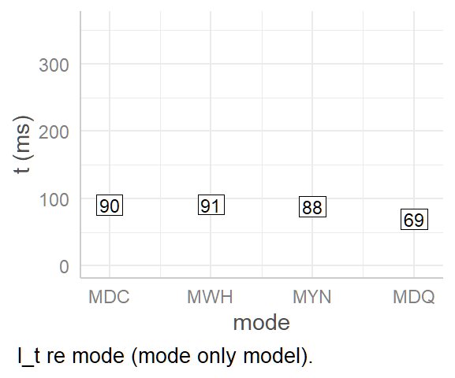

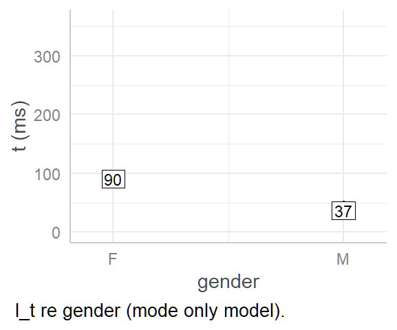

```r
l_t_mode_only.tidy <- analyseModel(
  l_t_mode_only_mdl,
  write = "output/l_t_mode_only",
  print_r2 = F,
  short_caption = T,
  y_lim = y_lim_t,
  y_lab = "t (ms)",
  caption_suffix = " (mode only model)",
  plot_rounding = 0
)
```

```r
printTidyPredictions(l_t_mode_only_mdl,
  digits = 0,
  caption_suffix = " (mode only model)"
)
```

Predicted values of l_t (mode only model)

| mode | predicted | conf.low | conf.high | std.error |
| --- | --- | --- | --- | --- |
| MDC | 90 | 76 | 105 | 8 |
| MWH | 91 | 76 | 106 | 8 |
| MYN | 88 | 73 | 103 | 8 |
| MDQ | 69 | 55 | 84 | 7 |

Predicted values of l_t (mode only model)

| gender | predicted | conf.low | conf.high | std.error |
| --- | --- | --- | --- | --- |
| F | 90 | 76 | 105 | 8 |
| M | 37 | 21 | 53 | 8 |

##### Effect Sizes

```r
l_t_mode_only.tidy$r2
```

Conditional and marginal R<sup>2</sup>

| marginal R<sup>2</sup> | conditional R<sup>2</sup> |
| --- | --- |
| .57 | .76 |

```r
l_t_mode_only.summary$omega2
```

Omega<sup>2</sup> (partial) for Dependent variable.

| Parameter | ω<sup>2</sup><sub>*p*</sub> | 95% CI |
| --- | --- | --- |
| mode | .17 | [.12, .22] |
| gender | .76 | [.34, .89] |

##### Pairwise comparisons

```r
charts <- getModelFixedFX(
  l_t_mode_only_mdl,
  write = write
)
```

```
## l_t ~ mode + gender + (1 | speaker) + (1 | fin_phon) + (1 | prompt)
```

```r
charts$slopes %>% tidyStatNumbers(digits = 1)
```

b1: l_t ~ mode + gender + (1 | speaker) + (1 | fin_phon) + (1 | prompt)

| intercept | slope | estimate | conf.low | conf.high | std.error | t.value | df | p.value |
| --- | --- | --- | --- | --- | --- | --- | --- | --- |
| modeMDC | modeMWH | 0.4 | -3.5 | 4.3 | 2 | 0.21 | 610.97 | .837 |
| modeMDC | modeMYN | -2.3 | -6.2 | 1.7 | 2.02 | -1.13 | 611.78 | .259 |
| modeMDC | modeMDQ | -21.0 | -25.2 | -16.8 | 2.14 | -9.78 | 598.82 | < .001 |
| modeMWH | modeMYN | -2.7 | -6.6 | 1.3 | 2.01 | -1.34 | 612.04 | .182 |
| modeMWH | modeMDQ | -21.4 | -25.6 | -17.2 | 2.14 | -9.97 | 597.81 | < .001 |
| modeMYN | modeMDQ | -18.7 | -22.8 | -14.6 | 2.1 | -8.9 | 609.62 | < .001 |
| intercept | genderM | -53.6 | -73.8 | -33.4 | 8.92 | -6.01 | 8.97 | < .001 |

##### ANOVA

```r
adjustP_posthoc("output/",
  p.value,
  suffix_id = "_anova"
)


read_csv(paste0(write, "_anova.csv")) %>%
  tidyStatNumbers() %>%
  formattable(caption = paste(
    "ANOVA of model:",
    getModelFormula(l_t_mode_only_mdl)
  ))
```

ANOVA of model: l_t ~ mode + gender + (1 | speaker) + (1 | fin_phon) + (1 | prompt)

| term | sumsq | meansq | NumDF | DenDF | F value | p.value | p.adj (BH) | signif. |
| --- | --- | --- | --- | --- | --- | --- | --- | --- |
| mode | 41965 | 13988 | 3 | 607.5 | 43.71 | < .001 | < .001 | *p* < .05 |
| gender | 11551 | 11551 | 1 | 8.97 | 36.09 | < .001 | < .001 | *p* < .05 |